# STIMA DEI LIVELLI DI OBESITÀ IN BASE ALLE ABITUDINI ALIMENTARI E ALLE CONDIZIONI FISICHE

### Tesina di Apprendimento Statistico - MACHINE LEARNING

**Elisabetta Roviera s328422**

## ABSTRACT

Questa tesina affronta il problema della **classificazione dei livelli di obesità in base alle abitudini alimentari e alle condizioni fisiche**. L'approccio proposto prevede un'analisi statistico-matematica del dataset per classificare i record. Nel corso dell'elaborato sono stati analizzati due algoritmi di classificazione e un algoritmo di apprendimento non supervisionato. Si è applicata la **PCA** (Principal Component Analysis) al dataset e, successivamente, i classificatori **RandomForest** e **GradientBoosting**.

Si è condotta una selezione empirica delle features (**features selection**) e degli iperparametri ottimali (**grid search con cross validation**) per addestrare i modelli di classificazione. L'analisi è stata effettuata due volte: tenendo in considerazione tutti i possibili target o effettuando una classificazione binaria. L'approccio proposto ottiene risultati complessivamente soddisfacenti.

## LIBRERIE

Di seguito è riportata la lista delle librerie utilizzate durante tutta l'analisi.

```python
import pandas as pd
import numpy as np
from sklearn.preprocessing import LabelEncoder
from IPython.display import display
import matplotlib.pyplot as plt
import seaborn as sns
from matplotlib.lines import Line2D
from sklearn.model_selection import train_test_split
from sklearn.preprocessing import MinMaxScaler
from sklearn.decomposition import PCA
from matplotlib.cm import viridis
from sklearn.ensemble import RandomForestClassifier
from sklearn.metrics import f1_score, precision_score, recall_score, confusion_matrix
from sklearn.metrics import make_scorer, accuracy_score, classification_report
from sklearn.metrics import ConfusionMatrixDisplay
from sklearn.model_selection import GridSearchCV
from sklearn.ensemble import GradientBoostingClassifier
```

## OVERVIEW DEL PROBLEMA

Il dataset è stato scaricato dal sito ufficiale di UC Irvine. **[1]**

Questo dataset include dati per la stima dei livelli di obesità negli individui dei paesi *Messico*, *Perù* e *Colombia*, in base alle loro abitudini alimentari e alle loro condizioni fisiche. I dati contengono $16$ feature, $2111$ record e $1$ target. I record sono etichettati con la variabile di classe **NObesity** (Obesity Level), che permette di classificare i dati utilizzando i valori di *Insufficient Weight*, *Normal Weight*, *Overweight Level I*, *Overweight Level II*, *Obesity Type I*, *Obesity Type II* e *Obesity Type III*. Il $77\%$ dei dati è stato generato sinteticamente utilizzando lo strumento **Weka** e il filtro **SMOTE**, mentre il $23\%$ dei dati è stato raccolto direttamente dagli utenti attraverso una piattaforma web.

**Sovrappeso e obesità** sono definiti dall'Organizzazione Mondiale della Sanità (OMS) come condizioni di anormale o eccessivo accumulo di grasso corporeo.

Il *3 maggio 2022* l'Ufficio regionale europeo del *OMS* ha presentato e pubblicato il Rapporto 2022 sull'obesità nella Regione che evidenzia tassi di sovrappeso e obesità che hanno raggiunto proporzioni epidemiche in questa parte del mondo. Dal documento emerge che il $59\%$ degli adulti europei e quasi $1$ bambino su $3$ ($29\%$ dei maschi e $27\%$ delle femmine) è in sovrappeso o è affetto dall’obesità, ormai considerata una vera e propria malattia. Sovrappeso e obesità sono infatti tra le principali cause di morte e disabilità nella Regione europea del *OMS* e stime recenti suggeriscono che causano più di $1.2$ milioni di decessi all'anno, corrispondenti a oltre il $13\%$ della mortalità totale nella Regione. **[2]**

L'**obesità** è causata da fattori *biologici* (per almeno un $30\%$ genetici), *psicologici* e *socio-ambientali* ma, in ogni caso, l'eccesso ponderale è causato da uno squilibrio fra assunzione calorica e spesa energetica a favore della prima.

L'indice più comunemente utilizzato per il calcolo dell'obesità è il **Body Mass Index (BMI)** che si ottiene dal peso *W* (in $kg$) diviso per la statura *H* (in $m$), ovvero $$ BMI = \frac{W}{H^2} $$

Con tale indice quindi, i dati vengono divisi nelle seguenti classi **[3]**

1. **Insufficient Weight** $BMI < 18.5$
2. **Normal Weight** $18.5 \leq BMI \leq 24.9$
3. **Overweight Level I** $25.0 \leq BMI \leq 29.9$
4. **Overweight Level II** $25.0 \leq BMI \leq 29.9$
5. **Obesity Type I** $30.0 \leq BMI \leq 34.9$
6. **Obesity Type II** $35.0 \leq BMI \leq 39.9$
7. **Obesity Type III** $40.0 \leq BMI$

### DATASET

Importiamo il dataset con il comando *read_csv* utilizzando il parametro di default *header = 0* in modo da mantenere l'intestazione delle colonne, già fornita dal file scaricato dal sito di riferimento.

```python
# Importazione del dataset da file csv
df_obesity = pd.read_csv("ObesityDataSet_raw_and_data_sinthetic.csv")
```

## DATA EXPLORATION

In questo paragrafo si esplora il **dataset** per prendere confidenza con i dati.

- Con il comando *head* si visualizzano le prime 5 istanze del dataset
- Col il comando *tail* si visualizzano le ultime 5 istanze del dataset
- Con il comando *columns* si visualizzano i nomi delle colonne del dataset
- Con il comando *info* si verifica la presenza di dati mancanti o nulli e la natura delle feature (**object**, **float**)
- Con il comando *describe* si ottengono le prime informazioni statistiche sulle feature

```python
# Prime righe del dataset
df_obesity.head()
```

|  | Gender | Age | Height | Weight | family_history_with_overweight | FAVC | FCVC | NCP | CAEC | SMOKE | CH2O | SCC | FAF | TUE | CALC | MTRANS | NObeyesdad |
| --- | --- | --- | --- | --- | --- | --- | --- | --- | --- | --- | --- | --- | --- | --- | --- | --- | --- |
| 0 | Female | 21.0 | 1.62 | 64.0 | yes | no | 2.0 | 3.0 | Sometimes | no | 2.0 | no | 0.0 | 1.0 | no | Public_Transportation | Normal_Weight |
| 1 | Female | 21.0 | 1.52 | 56.0 | yes | no | 3.0 | 3.0 | Sometimes | yes | 3.0 | yes | 3.0 | 0.0 | Sometimes | Public_Transportation | Normal_Weight |
| 2 | Male | 23.0 | 1.80 | 77.0 | yes | no | 2.0 | 3.0 | Sometimes | no | 2.0 | no | 2.0 | 1.0 | Frequently | Public_Transportation | Normal_Weight |
| 3 | Male | 27.0 | 1.80 | 87.0 | no | no | 3.0 | 3.0 | Sometimes | no | 2.0 | no | 2.0 | 0.0 | Frequently | Walking | Overweight_Level_I |
| 4 | Male | 22.0 | 1.78 | 89.8 | no | no | 2.0 | 1.0 | Sometimes | no | 2.0 | no | 0.0 | 0.0 | Sometimes | Public_Transportation | Overweight_Level_II |

```python
# Ultime righe del dataset
df_obesity.tail()
```

|  | Gender | Age | Height | Weight | family_history_with_overweight | FAVC | FCVC | NCP | CAEC | SMOKE | CH2O | SCC | FAF | TUE | CALC | MTRANS | NObeyesdad |
| --- | --- | --- | --- | --- | --- | --- | --- | --- | --- | --- | --- | --- | --- | --- | --- | --- | --- |
| 2106 | Female | 20.976842 | 1.710730 | 131.408528 | yes | yes | 3.0 | 3.0 | Sometimes | no | 1.728139 | no | 1.676269 | 0.906247 | Sometimes | Public_Transportation | Obesity_Type_III |
| 2107 | Female | 21.982942 | 1.748584 | 133.742943 | yes | yes | 3.0 | 3.0 | Sometimes | no | 2.005130 | no | 1.341390 | 0.599270 | Sometimes | Public_Transportation | Obesity_Type_III |
| 2108 | Female | 22.524036 | 1.752206 | 133.689352 | yes | yes | 3.0 | 3.0 | Sometimes | no | 2.054193 | no | 1.414209 | 0.646288 | Sometimes | Public_Transportation | Obesity_Type_III |
| 2109 | Female | 24.361936 | 1.739450 | 133.346641 | yes | yes | 3.0 | 3.0 | Sometimes | no | 2.852339 | no | 1.139107 | 0.586035 | Sometimes | Public_Transportation | Obesity_Type_III |
| 2110 | Female | 23.664709 | 1.738836 | 133.472641 | yes | yes | 3.0 | 3.0 | Sometimes | no | 2.863513 | no | 1.026452 | 0.714137 | Sometimes | Public_Transportation | Obesity_Type_III |

```python
# Nomi delle colonne del dataset
df_obesity.columns
```

```
Index(['Gender', 'Age', 'Height', 'Weight', 'family_history_with_overweight',
       'FAVC', 'FCVC', 'NCP', 'CAEC', 'SMOKE', 'CH2O', 'SCC', 'FAF', 'TUE',
       'CALC', 'MTRANS', 'NObeyesdad'],
      dtype='object')
```

Quelli correlati alle condizioni fisiche sono

1. **Gender** - Female, Male
2. **Age** - numeric
3. **Height** - numeric
4. **Weight** - numeric
5. Calories consumption monitoring **SCC** - yes, no
6. Physical activity frequency **FAF** - numeric
7. Time using technology devices **TUE** - numeric
8. Transportation used **MTRANS** - Automobile, Motorbike, Bike, Public_Transportation, Walking

Infine, altri attributi sono

1. **Family history** - yes, no
2. **Smoke** - yes, no

L'ultima colonna **NObeyesdad** rappresenta la variabile target utilizzata per la calssificazione.

##### Si visualizzino ora le statistiche per tutte le colonne.

```python
df_obesity.describe(include='all')
```

|  | Gender | Age | Height | Weight | family_history_with_overweight | FAVC | FCVC | NCP | CAEC | SMOKE | CH2O | SCC | FAF | TUE | CALC | MTRANS | NObeyesdad |
| --- | --- | --- | --- | --- | --- | --- | --- | --- | --- | --- | --- | --- | --- | --- | --- | --- | --- |
| count | 2111 | 2111.000000 | 2111.000000 | 2111.000000 | 2111 | 2111 | 2111.000000 | 2111.000000 | 2111 | 2111 | 2111.000000 | 2111 | 2111.000000 | 2111.000000 | 2111 | 2111 | 2111 |
| unique | 2 | NaN | NaN | NaN | 2 | 2 | NaN | NaN | 4 | 2 | NaN | 2 | NaN | NaN | 4 | 5 | 7 |
| top | Male | NaN | NaN | NaN | yes | yes | NaN | NaN | Sometimes | no | NaN | no | NaN | NaN | Sometimes | Public_Transportation | Obesity_Type_I |
| freq | 1068 | NaN | NaN | NaN | 1726 | 1866 | NaN | NaN | 1765 | 2067 | NaN | 2015 | NaN | NaN | 1401 | 1580 | 351 |
| mean | NaN | 24.312600 | 1.701677 | 86.586058 | NaN | NaN | 2.419043 | 2.685628 | NaN | NaN | 2.008011 | NaN | 1.010298 | 0.657866 | NaN | NaN | NaN |
| std | NaN | 6.345968 | 0.093305 | 26.191172 | NaN | NaN | 0.533927 | 0.778039 | NaN | NaN | 0.612953 | NaN | 0.850592 | 0.608927 | NaN | NaN | NaN |
| min | NaN | 14.000000 | 1.450000 | 39.000000 | NaN | NaN | 1.000000 | 1.000000 | NaN | NaN | 1.000000 | NaN | 0.000000 | 0.000000 | NaN | NaN | NaN |
| 25% | NaN | 19.947192 | 1.630000 | 65.473343 | NaN | NaN | 2.000000 | 2.658738 | NaN | NaN | 1.584812 | NaN | 0.124505 | 0.000000 | NaN | NaN | NaN |
| 50% | NaN | 22.777890 | 1.700499 | 83.000000 | NaN | NaN | 2.385502 | 3.000000 | NaN | NaN | 2.000000 | NaN | 1.000000 | 0.625350 | NaN | NaN | NaN |
| 75% | NaN | 26.000000 | 1.768464 | 107.430682 | NaN | NaN | 3.000000 | 3.000000 | NaN | NaN | 2.477420 | NaN | 1.666678 | 1.000000 | NaN | NaN | NaN |
| max | NaN | 61.000000 | 1.980000 | 173.000000 | NaN | NaN | 3.000000 | 4.000000 | NaN | NaN | 3.000000 | NaN | 3.000000 | 2.000000 | NaN | NaN | NaN |

```python
# Informazioni principali del dataset
df_obesity.info()
```

```
<class 'pandas.core.frame.DataFrame'>
RangeIndex: 2111 entries, 0 to 2110
Data columns (total 17 columns):
 #   Column                          Non-Null Count  Dtype
---  ------                          --------------  -----
 0   Gender                          2111 non-null   object
 1   Age                             2111 non-null   float64
 2   Height                          2111 non-null   float64
 3   Weight                          2111 non-null   float64
 4   family_history_with_overweight  2111 non-null   object
 5   FAVC                            2111 non-null   object
 6   FCVC                            2111 non-null   float64
 7   NCP                             2111 non-null   float64
 8   CAEC                            2111 non-null   object
 9   SMOKE                           2111 non-null   object
 10  CH2O                            2111 non-null   float64
 11  SCC                             2111 non-null   object
 12  FAF                             2111 non-null   float64
 13  TUE                             2111 non-null   float64
 14  CALC                            2111 non-null   object
 15  MTRANS                          2111 non-null   object
 16  NObeyesdad                      2111 non-null   object
dtypes: float64(8), object(9)
memory usage: 280.5+ KB
```

### ENCODING

Si noti che non sono presenti valori nulli. Ma ci sono nove attributi di tipo *object*. Risulta quindi necessario effettuare qualche operazione di **encoding** per ottenere solo dati numerici.

Il **LABEL ENCODING** è una tecnica utilizzata per convertire le colonne categoriche in colonne numeriche, in modo che possano essere adattate da modelli di machine learning che accettano solo dati numerici. È un'importante fase di pre-processing. Per la colonna dei target utilizzeremo un **label encoding**, ovvero, avendo 7 classi, assoceremo ad ognuna di esse un numero compreso tra 0 e 6. **[4]**

Per le variabili categoriali in cui non esiste una relazione ordinale, la label encoding non è sufficiente. Infatti, utilizzando questa codifica e lasciando che il modello assuma un ordinamento naturale tra le categorie, si possono ottenere prestazioni scarse o risultati inaspettati (previsioni a metà strada tra le categorie).

Il **ONE-HOT ENCODING** aggiunge una variabile per ogni valore assumibile dalla feature. Si utilizza quindi un **one-hot** encoding per tutti gli altri valori di tipo object. Questo metodo trasforma ogni attributo in un vettore binario di lunghezza pari al numero totale di valori categorici possibili. L'entrata associata al valore corretto corrisponderà all'$1$, mentre per le altre verrà posto lo $0$. **[5]**

```python
# Copia del dataset
df = df_obesity.copy()

# Rinominazione della colonna target NObeyesdad
df.rename(columns={'NObeyesdad':'CLASS'},inplace=True)

# Trasformazione da 'object' a 'category'
df = df.astype({"Gender": 'category', "family_history_with_overweight": 'category',
                'FAVC':'category', 'CAEC':'category', 'SMOKE':'category', 'SCC':'category',
                'CALC':'category', 'CALC':'category', 'MTRANS':'category',
                'CLASS':'category'})

# Label encoding per la colonna CLASS rappresentante i target
labelenc_class = LabelEncoder()
labelenc_class.fit(df['CLASS'].values)
df['CLASS'] = labelenc_class.transform(df['CLASS'].values)

# One-hot encoding per gli altri attributi
onehot_cols = ['Gender','family_history_with_overweight', 'FAVC', 'CAEC', 'SMOKE',
               'SCC', 'CALC', 'MTRANS']
df = pd.get_dummies(df, columns=onehot_cols)
```

```python
# Loop attraverso le colonne e converti i valori booleani Ture/False in 1/0
for column in df.columns:
    if df[column].dtype == 'bool':
        df[column] = df[column].astype(int)
```

```python
df.info()
```

```
<class 'pandas.core.frame.DataFrame'>
RangeIndex: 2111 entries, 0 to 2110
Data columns (total 32 columns):
 #   Column                              Non-Null Count  Dtype
---  ------                              --------------  -----
 0   Age                                 2111 non-null   float64
 1   Height                              2111 non-null   float64
 2   Weight                              2111 non-null   float64
 3   FCVC                                2111 non-null   float64
 4   NCP                                 2111 non-null   float64
 5   CH2O                                2111 non-null   float64
 6   FAF                                 2111 non-null   float64
 7   TUE                                 2111 non-null   float64
 8   CLASS                               2111 non-null   int32
 9   Gender_Female                       2111 non-null   int32
```

[output cut: 24 more lines]

```python
# Il nuovo dataset risulta quindi
df
```

|  | Age | Height | Weight | FCVC | NCP | CH2O | FAF | TUE | CLASS | Gender_Female | ... | SCC_yes | CALC_Always | CALC_Frequently | CALC_Sometimes | CALC_no | MTRANS_Automobile | MTRANS_Bike | MTRANS_Motorbike | MTRANS_Public_Transportation | MTRANS_Walking |
| --- | --- | --- | --- | --- | --- | --- | --- | --- | --- | --- | --- | --- | --- | --- | --- | --- | --- | --- | --- | --- | --- |
| 0 | 21.000000 | 1.620000 | 64.000000 | 2.0 | 3.0 | 2.000000 | 0.000000 | 1.000000 | 1 | 1 | ... | 0 | 0 | 0 | 0 | 1 | 0 | 0 | 0 | 1 | 0 |
| 1 | 21.000000 | 1.520000 | 56.000000 | 3.0 | 3.0 | 3.000000 | 3.000000 | 0.000000 | 1 | 1 | ... | 1 | 0 | 0 | 1 | 0 | 0 | 0 | 0 | 1 | 0 |
| 2 | 23.000000 | 1.800000 | 77.000000 | 2.0 | 3.0 | 2.000000 | 2.000000 | 1.000000 | 1 | 0 | ... | 0 | 0 | 1 | 0 | 0 | 0 | 0 | 0 | 1 | 0 |
| 3 | 27.000000 | 1.800000 | 87.000000 | 3.0 | 3.0 | 2.000000 | 2.000000 | 0.000000 | 5 | 0 | ... | 0 | 0 | 1 | 0 | 0 | 0 | 0 | 0 | 0 | 1 |
| 4 | 22.000000 | 1.780000 | 89.800000 | 2.0 | 1.0 | 2.000000 | 0.000000 | 0.000000 | 6 | 0 | ... | 0 | 0 | 0 | 1 | 0 | 0 | 0 | 0 | 1 | 0 |
| ... | ... | ... | ... | ... | ... | ... | ... | ... | ... | ... | ... | ... | ... | ... | ... | ... | ... | ... | ... | ... | ... |
| 2106 | 20.976842 | 1.710730 | 131.408528 | 3.0 | 3.0 | 1.728139 | 1.676269 | 0.906247 | 4 | 1 | ... | 0 | 0 | 0 | 1 | 0 | 0 | 0 | 0 | 1 | 0 |
| 2107 | 21.982942 | 1.748584 | 133.742943 | 3.0 | 3.0 | 2.005130 | 1.341390 | 0.599270 | 4 | 1 | ... | 0 | 0 | 0 | 1 | 0 | 0 | 0 | 0 | 1 | 0 |
| 2108 | 22.524036 | 1.752206 | 133.689352 | 3.0 | 3.0 | 2.054193 | 1.414209 | 0.646288 | 4 | 1 | ... | 0 | 0 | 0 | 1 | 0 | 0 | 0 | 0 | 1 | 0 |
| 2109 | 24.361936 | 1.739450 | 133.346641 | 3.0 | 3.0 | 2.852339 | 1.139107 | 0.586035 | 4 | 1 | ... | 0 | 0 | 0 | 1 | 0 | 0 | 0 | 0 | 1 | 0 |
| 2110 | 23.664709 | 1.738836 | 133.472641 | 3.0 | 3.0 | 2.863513 | 1.026452 | 0.714137 | 4 | 1 | ... | 0 | 0 | 0 | 1 | 0 | 0 | 0 | 0 | 1 | 0 |

2111 rows × 32 columns

Dopo aver ristampato il dataset, si può notare che correttamete tutti gli attributi ora sono numerici

- **int32** corrisponde ai valori 0/1 rappresentanti False/True per la one-hot encoding
- **float64** corrisponde ai valori pre-esistenti di float

Si noti inoltre che le dimensioni del $df$ sono cambiate. Il numero di istanze è giustamente lo stesso. Invece, il numero di colonne è aumentato in quanto ne viene creata una nuova per ogni valore assumibile dalle features.

Per esempio, la colonna *Gender* è stata rimpiazzata dalle colonne *Gender_Female* e *Gender_Male*.

Si salva in classes il nome dei target associati alla numerazione assegnata dal label encoding.

```python
classes = dict(zip(labelenc_class.classes_, labelenc_class.transform(labelenc_class.classes_)))
classes
```

```
{'Insufficient_Weight': 0,
 'Normal_Weight': 1,
 'Obesity_Type_I': 2,
 'Obesity_Type_II': 3,
 'Obesity_Type_III': 4,
 'Overweight_Level_I': 5,
 'Overweight_Level_II': 6}
```

## DATA VISUALIZATION

### BILANCIAMENTO DEL DATASET

Si verifica ora se il $df$ è bilanciato. Risulta, infatti, molto importante che la classe dei target sia abbastanza equilibrata, nel senso che non ci siano sproporzioni tra le differenti classi. Si inizi col contare quanti individui appartengono ad ogni classe e calcolarne la frequenza. Come si può notare dalla tabella e dal plot, **il dataset risulta ben bilanciato.**

```python
class_cont_freq = pd.concat([pd.Series(labelenc_class.classes_),
                        df['CLASS'].value_counts(), df['CLASS'].value_counts()/df.shape[0]],
                        axis=1)
class_cont_freq.columns = ['classe','quantità', 'frequenza']
class_cont_freq.index.name = 'CLASS'

class_cont_freq
```

| CLASS | classe | quantità | frequenza |
| --- | --- | --- | --- |
| 0 | Insufficient_Weight | 272 | 0.128849 |
| 1 | Normal_Weight | 287 | 0.135955 |
| 2 | Obesity_Type_I | 351 | 0.166272 |
| 3 | Obesity_Type_II | 297 | 0.140692 |
| 4 | Obesity_Type_III | 324 | 0.153482 |
| 5 | Overweight_Level_I | 290 | 0.137376 |
| 6 | Overweight_Level_II | 290 | 0.137376 |

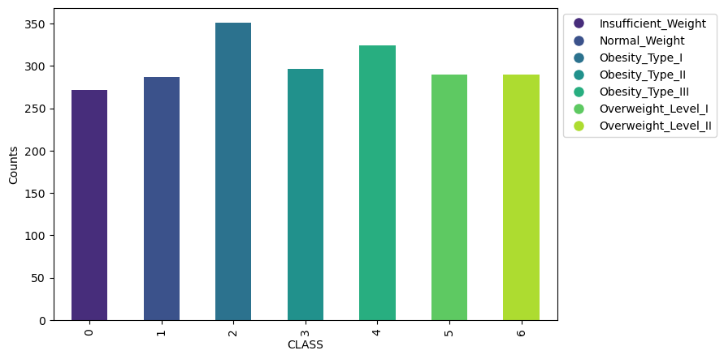

```python
class_labels = {
    0: 'Insufficient_Weight',
    1: 'Normal_Weight',
    2: 'Obesity_Type_I',
    3: 'Obesity_Type_II',
    4: 'Obesity_Type_III',
    5: 'Overweight_Level_I',
    6: 'Overweight_Level_II'
}

# Mapping tra valori di classe e i colori
class_colors = sns.color_palette('viridis', n_colors=len(class_labels))

# Creazione del bar graph
plt.figure(figsize=(8, 5))
ordered_classes = df['CLASS'].value_counts().sort_index()
ordered_classes.plot(kind='bar', color=class_colors)

legend_handles = [Line2D([0], [0], marker='o', color='w', markerfacecolor=color,
                         markersize=10) for color in class_colors]
legend_labels = [class_labels[key] for key in ordered_classes.index]
plt.legend(legend_handles, legend_labels, loc='upper left', bbox_to_anchor=(1, 1))

plt.xlabel('CLASS')
plt.ylabel('Counts')
plt.show()
```

### RELAZIONE TRA CLASS E ALCUNE FEATURES DI INTERESSE

Tramite **box plot** e la **matrice di correlazione** è possibile visualizzare la correlazione tra le features e la variabile target.

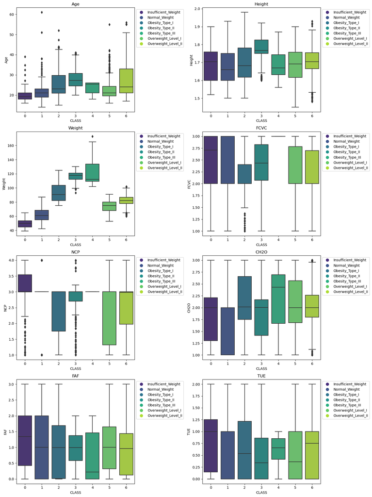

```python
# Colonnes di interesse (numeriche)
columns = ['Age', 'Height', 'Weight', 'FCVC', 'NCP', 'CH2O', 'FAF', 'TUE']

class_labels = {
    0: 'Insufficient_Weight',
    1: 'Normal_Weight',
    2: 'Obesity_Type_I',
    3: 'Obesity_Type_II',
    4: 'Obesity_Type_III',
    5: 'Overweight_Level_I',
    6: 'Overweight_Level_II'
}

class_colors = sns.color_palette('viridis', n_colors=len(class_labels))
rows = (len(columns) + 1) // 2
cols = 2

fig, axes = plt.subplots(rows, cols, figsize=(15, 5 * rows))
axes = axes.flatten()
# Box plot
for i, col in enumerate(columns):
    sns.boxplot(data=df, x='CLASS', y=col, palette=class_colors, ax=axes[i])
    axes[i].set_title(col)
    handles = [plt.Line2D([0], [0], marker='o', color='w', label=f'{class_labels[cls]}',
            markerfacecolor=color, markersize=10)
            for cls, color in zip(class_labels.keys(), class_colors)]
    axes[i].legend(handles=handles, loc='upper left', bbox_to_anchor=(1, 1))

plt.tight_layout()
plt.show()
```

### MATRICE DI CORRELAZIONE

Si plotta la matrice di correlazione del dataset originale dove vengono prese in considerazione solo le features numeriche. Si noti come le features risultano poco correlate.

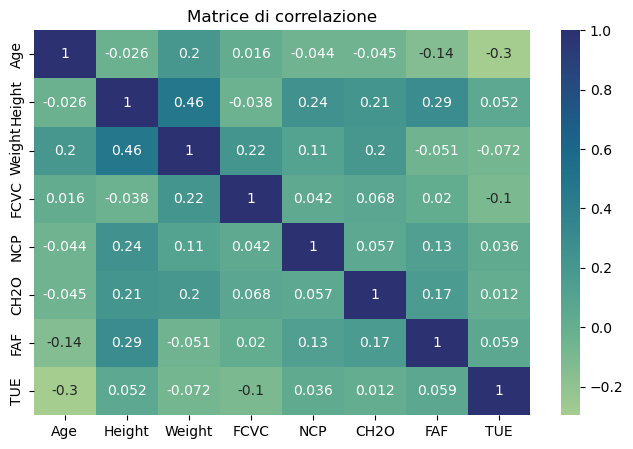

```python
plt.figure(figsize=(8, 5))
plt.title('Matrice di correlazione')

# Seleziona solo le colonne numeriche
numerical_columns = df_obesity.select_dtypes(include=[np.number])
corrMatrix = numerical_columns.corr(method="pearson")
sns.heatmap(corrMatrix, annot=True, cmap="crest")
plt.show()
```

### CLASSIFICAZIONE BINARIA

Si affronta ora un **problema di classificazione binaria**. Il valore $1$ rappresenta le persone classificate come non obese e $0$ per tutte le altre categorie. Verranno considerate allora come **non obese** le classi *Insufficient Weight*, *Normal Weight*, *Overweight Level I* e *Overweight Level 2*, mentre le classi delle persone **obese** saranno *Obesity Type I*, *Obesity Type II* e *Obesity Type III*.

Si noti che anche per la classificazione binaria il dataset risulta bilanciato.

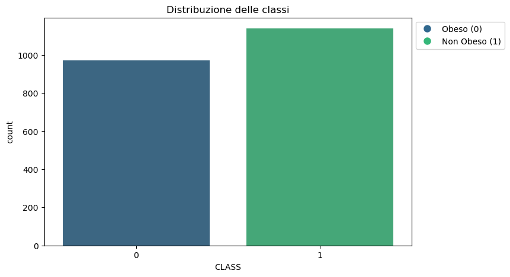

```python
# Copia del dataset per la classificazione binaria
df_binary = df.copy()

# Creare un mapping per la sostituzione
class_mapping = {2: 0, 3: 0, 4: 0, 0: 1, 1: 1, 5: 1, 6: 1}
df_binary['CLASS'] = df_binary['CLASS'].map(class_mapping)
class_colors = sns.color_palette('viridis', n_colors=len(df_binary['CLASS'].unique()))

# Bar plot
plt.figure(figsize=(8, 5))
sns.countplot(x='CLASS', data=df_binary, palette=class_colors)
legend_handles = [Line2D([0], [0], marker='o', color='w', markerfacecolor=color,
                         markersize=10) for color in class_colors]
legend_labels = ['Obeso (0)', 'Non Obeso (1)']
plt.legend(legend_handles, legend_labels, loc='upper left', bbox_to_anchor=(1, 1))
plt.title('Distribuzione delle classi')
plt.show()
```

### SPLIT DEI DATI E NORMALIZZAZIONE

Si suddividano ora i dati in **Training** e **Test** set. Si riscalino quindi i dati di Training e si applichi la stessa trasformazione ai dati di Test. Per riscalare i dati è stato usato il **MinMaxScaler**.

**MinMaxScaler** è una tecnica di normalizzazione utilizzata nell'ambito del machine learning per trasformare le caratteristiche di un dataset in un intervallo specifico. Questa tecnica è particolarmente utile quando le caratteristiche del dataset hanno scale diverse o quando si desidera che le caratteristiche si trovino in un range specifico. La trasformazione effettuata da MinMaxScaler può essere descritta come segue. Supponiamo di avere un vettore di dati $X$, che rappresenta una caratteristica del dataset. MinMaxScaler trasforma ogni elemento $x$ di $X$ secondo la seguente formula

$$X_{\text{scaled}} = \frac{X - X_{\text{min}}}{X_{\text{max}} - X_{\text{min}}}$$

Dove

- $X_{\text{scaled}}$ è il valore normalizzato di $X$
- $X_{\text{min}}$ è il valore minimo della caratteristica $X$ nel dataset
- $X_{\text{max}}$ è il valore massimo della caratteristica $X$ nel dataset

In altre parole, MinMaxScaler scala i dati in modo che siano compresi tra $0$ e $1$. **[7]**

```python
X = pd.DataFrame(df.drop(columns="CLASS")) # Escludo i target
y = df["CLASS"]

# Split dei dati in training e test
test_p = 0.2
X_train, X_test, y_train, y_test = train_test_split(X, y, test_size=test_p,
                                                    shuffle=True, random_state=42)

# Standardizziamo i dati
scaler = MinMaxScaler()
scaler.fit(X_train) # SOLO dati di training

X_train_scaled = pd.DataFrame(scaler.transform(X_train), columns=X_train.columns)
X_test_scaled = pd.DataFrame(scaler.transform(X_test), columns=X_test.columns)

# Concatena i dati standardizzati
X_scaled = pd.concat([X_train_scaled, X_test_scaled], axis=0)
```

## PCA - Principal Component Analysis

La **riduzione della dimensionalità** è il processo che consiste nel prendere i dati in uno spazio ad alta dimensionalità e mapparli in un nuovo spazio la cui dimensionalità è molto più piccola. Questo processo è strettamente legato al concetto di compressione (con perdita) nella teoria dell'informazione. Ci sono diverse ragioni per ridurre la dimensionalità dei dati. In primo luogo, i dati ad alta dimensionalità impongono *sfide computazionali*. Inoltre, in alcune situazioni l'alta dimensionalità può portare a *scarse capacità di generalizzazione* dell'algoritmo di apprendimento. Infine, la riduzione della dimensionalità può essere utilizzata per interpretare i dati, anche a scopo illustrativo.

Nella **PCA**, sia la compressione che il recupero vengono eseguiti mediante *trasformazioni lineari*. Il metodo individua le trasformazioni lineari per le quali le dierenze tra i vettori recuperati e quelli originali sono minime nel senso dei minimi quadrati.

La **PCA** (Principal Component Anlalysis) è una tecnica di statistica multivariata. Lo scopo di questa tecnica è quello di ridurre il numero di variabili che descrivono un insieme di dati correlati a un numero minore di variabili scorrelate, cercando però di limitare la perdita di informazioni. In altre parole, attraverso questo metodo riusciamo a trovare la migliore mappa da $\mathbb{R}^d$ (spazio originario dei dati) a $\mathbb{R}^n$, con $n < d$. La PCA è un esempio di unsupervised learning, dunque un algoritmo che non possiede una variabile di risposta.

Nella PCA, si individua la matrice di compressione $W$ e la matrice di recupero $U$ in modo tale che la distanza quadratica totale tra i vettori originali e quelli recuperati sia minima; in altre parole, si mira a risolvere il problema

\begin{aligned} \underset{W \in \mathbb{R}^{n,d}, U \in \mathbb{R}^{d, n}}{\text{argmin}} & & \sum_{i = 1}^m \| x_i - UWx_i \|^2_2 \end{aligned}

Dove

- $x_i$ è l'i-esimo campione, ovvero l'i-esimo vettore $\in \mathbb{R}^{d,1}$ del campione $X = (x_1, \ldots, x_m)$
- $W$ è la matrice di compressione che proietta i dati da $\mathbb{R}^d$ a $\mathbb{R}^n$
- $U$ è la matrice di decompressione che proietta i dati da $\mathbb{R}^n$ a $\mathbb{R}^d$

Quindi, quando si applica $UWx_i$ ciò che si sta facendo è "ricostruire" i dati $x_i$ proiettandoli prima da $\mathbb{R}^d$ a $\mathbb{R}^n$ e poi riportandoli in $\mathbb{R}^d$. Appare quindi chiaro che l'obiettivo del problema di ottimizzazione è quello di minimizzare l'errore di tale ricostruzione.

Si può dimostrare che, prese due soluzioni $U$ e $W$, esse saranno tali che $U$ è ortogonale (ovvero $U'U = I$) e $W = U'$. Il problema di ottimizzazione allora, sfruttando questo fatto, si potrà riscrivere come

\begin{aligned} \underset{U \in \mathbb{R}^{d, n}, U'U = I}{\text{argmax}} & & \text{traccia} \biggl(U' \biggl( \sum_{i=1}^m x_i x_i' \biggr) U \biggr) \end{aligned}

Definendo la **scatter matrix** $ A = \sum_{i=1}^m x_i x_i'$ si arriva alla soluzione $U$. Quindi, $U$ è la matrice le cui colonne, $u_1, \ldots, u_n$, sono gli $n$ autovettori primi di $A$.**[6]**

Si applichi ora la **PCA** ai dati standardizzati `X_train_scaled` e non `X_train` per apprezzarne la differenza.

```python
pca_stand = PCA()
pca_nostand = PCA()

pca_stand.fit(X_train_scaled)
pca_nostand.fit(X_train)
```

```
PCA()
```

Il codice crea un confronto visivo tra la **varianza spiegata cumulativa** della **PCA** non standardizzata e di quella standardizzata, aiutando a valutare l'impatto della standardizzazione sulla riduzione della dimensionalità.

I plot sono, quindi, linee che rappresentano la varianza spiegata cumulativa in percentuale per ciascun componente principale, sia per PCA non standardizzata che per PCA standardizzata. Questi plot mostrano come la varianza complessiva viene spiegata accumulando i singoli componenti principali.

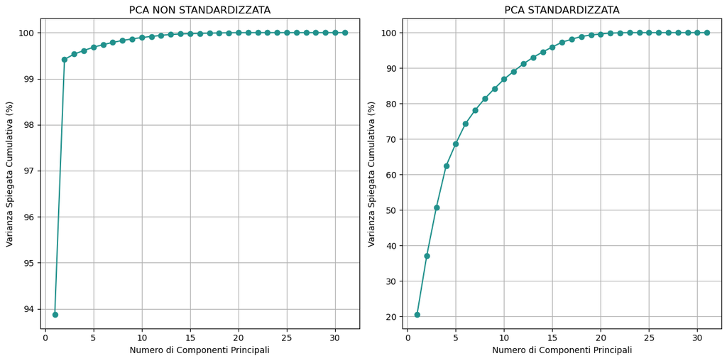

```python
fig, axes = plt.subplots(1, 2, figsize=(12, 6))

# Grafico PCA non standardizzata
cumulative_variance_nostand = np.cumsum(pca_nostand.explained_variance_ratio_) * 100
axes[0].plot(range(1, len(cumulative_variance_nostand) + 1),
             cumulative_variance_nostand, marker='o', linestyle='-', color=viridis(0.5))
axes[0].set_title('PCA NON STANDARDIZZATA')
axes[0].set_xlabel('Numero di Componenti Principali')
axes[0].set_ylabel('Varianza Spiegata Cumulativa (%)')
axes[0].grid()

# Grafico PCA standardizzata
cumulative_variance_stand = np.cumsum(pca_stand.explained_variance_ratio_) * 100
axes[1].plot(range(1, len(cumulative_variance_stand) + 1),
             cumulative_variance_stand, marker='o', linestyle='-', color=viridis(0.5))
axes[1].set_title('PCA STANDARDIZZATA')
axes[1].set_xlabel('Numero di Componenti Principali')
axes[1].set_ylabel('Varianza Spiegata Cumulativa (%)')
axes[1].grid()

plt.tight_layout()
plt.show()
```

Il codice fornisce un confronto visivo tra le **percentuali di varianza spiegata da ciascuna componente principale** in due analisi della componente principale (PCA): una con dati non standardizzati (PCA NON STANDARDIZZATA) e l'altra con dati standardizzati (PCA STANDARDIZZATA). Il grafico utilizza un formato a barre per rappresentare la varianza spiegata da ciascuna componente principale.

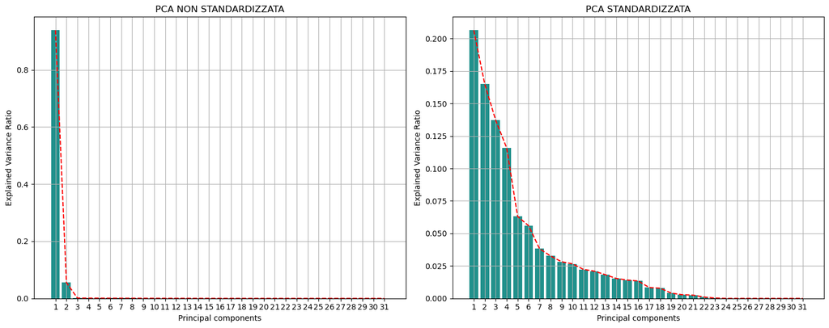

```python
fig, axes = plt.subplots(1, 2, figsize=(15, 6))

# Plot PCA non standardizzata
axes[0].bar(np.arange(pca_nostand.n_components_), pca_nostand.explained_variance_ratio_,
            color=viridis(0.5))
axes[0].plot(np.arange(pca_nostand.n_components_), pca_nostand.explained_variance_ratio_,
             'r--')
axes[0].set_title('PCA NON STANDARDIZZATA')
axes[0].set_xticks(ticks=np.arange(pca_nostand.n_components_),
                   labels=[f'{i}' for i in range(1, pca_nostand.n_components_ + 1)])
axes[0].set_xlabel('Principal components')
axes[0].set_ylabel('Explained Variance Ratio')
axes[0].grid()

# Plot PCA standardizzata
axes[1].bar(np.arange(pca_stand.n_components_), pca_stand.explained_variance_ratio_,
            color=viridis(0.5))
axes[1].plot(np.arange(pca_stand.n_components_), pca_stand.explained_variance_ratio_, 'r--')
axes[1].set_title('PCA STANDARDIZZATA')
axes[1].set_xticks(ticks=np.arange(pca_stand.n_components_),
                   labels=[f'{i}' for i in range(1, pca_stand.n_components_ + 1)])
axes[1].set_xlabel('Principal components')
axes[1].set_ylabel('Explained Variance Ratio')
axes[1].grid()

plt.tight_layout()
plt.show()
```

Il codice effettua l'analisi delle componenti principali (PCA) con varie soglie di varianza spiegata *explvar_p*. Per ogni valore specificato nel loop, si addestra un modello PCA sul set di dati di addestramento (*X_train_scaled*) e quindi trasformando l'intero set di dati ( *X_scaled*) utilizzando le componenti principali apprese. In sostanza, si esegue un'analisi PCA iterativa con diverse soglie di varianza spiegata e mostra i risultati in un DataFrame. La varianza spiegata aumenta all'aumentare delle componenti principali considerate.

```python
df_list = []
for i in [0.7, 0.75, 0.8, 0.85, 0.9, 0.95]:
    explvar_p = i

    pca_var = PCA(explvar_p)
    pca_var.fit(X_train_scaled) # Addestro solo su quelli di training
    y_var = pca_var.transform(X_scaled) # Trasformo tutti
    df_pca = pd.DataFrame({'value': [pca_var.n_components_,
                                     pca_var.explained_variance_ratio_.sum() * 100]},
                          index=['numero PC', 'varianza spiegata (%)'])
    df_list.append(df_pca)

result_df = pd.concat(df_list, axis=1)
display(result_df)
```

|  | value | value | value | value | value | value |
| --- | --- | --- | --- | --- | --- | --- |
| numero PC | 6.000000 | 7.000000 | 8.000000 | 10.000000 | 12.000000 | 14.000000 |
| varianza spiegata (%) | 74.311264 | 78.129151 | 81.397601 | 86.876841 | 91.204595 | 94.560198 |

### SCORE GRAPH

Nello score graph ogni dato ha una coordinata su una componente (**score**). Quando due componenti vengono rappresentate graficamente si ottiene una mappa in cui ogni dato è descritto da due coordinate, una per ciascuna componente. La mappa descrive similitudini e differenze tra i dati del campione: quelli vicini sono simili, mentre quelli molto distanti tra loro saranno molto diversi.

[figure not shown]

```python
plt.figure(figsize=(12, 5))

scatter = plt.scatter(y_var[:, 0], y_var[:, 1], c = df['CLASS'].values)
plt.title('SCORE GRAPH 2 PC')
plt.xlabel('PC1')
plt.ylabel('PC2')

label = ['Insufficient Weight','Normal Weight','Overweight Level I','Overweight Level II',
         'Obesity Type I','Obesity Type II','Obesity Type III',]
colors = df['CLASS'].astype('category').cat.codes
plt.legend(handles=scatter.legend_elements()[0], labels=label, fontsize = 'small',
           loc='upper left', bbox_to_anchor=(1, 1))
plt.grid()
plt.show()
```

### LOADING PLOTS

I **LOADING VECTORS** sono i pesi assegnati alle variabili originali per costruire ciascuna componente principale. Ogni variabile contribuisce a ciascuna componente principale in base al suo loading. I loading possono essere interpretati come la forza e la direzione della relazione tra la variabile originale e la componente principale.

I **LOADING PLOTS** sono dei grafici che visualizzano i loading vectors. I loading plots possono essere utili per interpretare la struttura delle componenti principali e comprendere quali variabili influenzano di più ciascuna componente.

I dati maggiormente distanti dall'origine avranno una presenza maggiore della componente nella direzione in cui si dispongono. Ad esempio, quelli in alto a sinistra avranno una maggior presenza della PC2, mentre una minore della PC1. Variabili vicine sono tra loro positivamente correlate e variabili con segno opposto su una componente sono negativamente correlate.

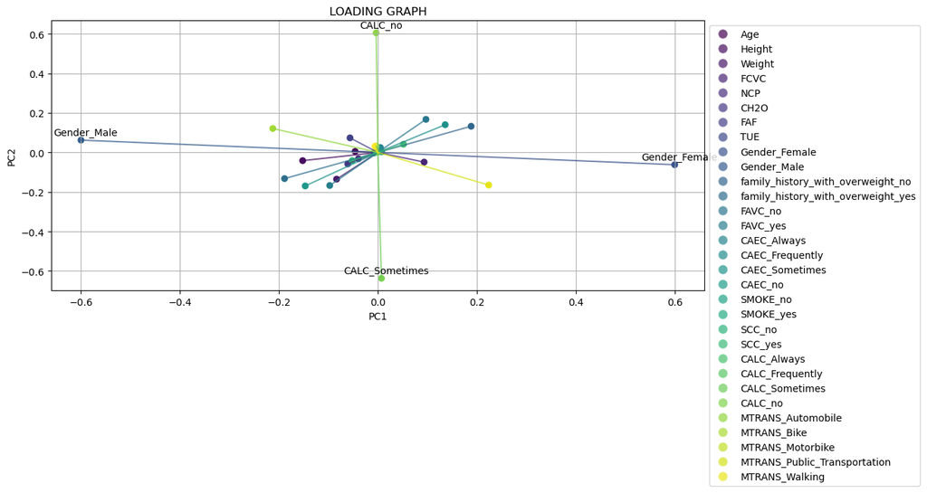

```python
legend_elements = [Line2D([0], [0], marker='o', color='w',
                          markerfacecolor=plt.cm.viridis(i / pca_var.n_features_in_, 0.7),
                          markersize=10, label=X_scaled.columns[i])
                   for i in range(pca_var.n_features_in_)]

plt.figure(figsize=(12, 5))
for i in range(pca_var.n_features_in_):
    plt.plot([0, pca_var.components_[0, i]], [0, pca_var.components_[1, i]],
             label=X_scaled.columns[i], color=plt.cm.viridis(i / pca_var.n_features_in_, 0.7))

    if X_scaled.columns[i] in ['Gender_Male', 'Gender_Female', 'CALC_no', 'CALC_Sometimes']:
        plt.annotate(X_scaled.columns[i],
                     (pca_var.components_[0, i], pca_var.components_[1, i]),
                     textcoords="offset points",
                     xytext=(5,5),
                     ha='center')

plt.scatter(pca_var.components_[0, :], pca_var.components_[1, :],
            c=range(pca_var.n_features_in_), cmap='viridis')
plt.legend(handles=legend_elements, bbox_to_anchor=(1, 1))
plt.title('LOADING GRAPH')
plt.xlabel('PC1')
plt.ylabel('PC2')
plt.grid()
plt.show()
```

### INTERPRETAZIONE DELLE PC

I grafici rappresentano i contributi delle diverse features alla prima e alla seconda componente principale (**PC1** e **PC2**) ottenute dalla **PCA**. In particolare

**PC1 (Prima Componente Principale)**. Il primo grafico mostra i pesi relativi di ciascuna feature sulla PC1. Le features con pesi più alti contribuiscono in modo più significativo alla PC1.

**PC2 (Seconda Componente Principale)**. Il secondo grafico rappresenta i pesi relativi delle features sulla PC2. Le features con pesi più alti contribuiscono in modo più significativo alla PC2.

L'asse x in entrambi i grafici rappresenta le diverse features (variabili) del dataset, mentre l'asse y rappresenta i pesi associati a ciascuna feature rispetto alle rispettive componenti principali. Questi grafici forniscono una visione delle principali direzioni di varianza nei dati e quali features sono più influenti in ciascuna di queste direzioni..

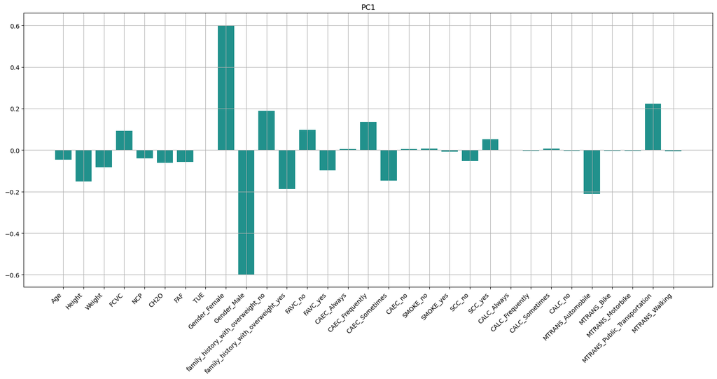

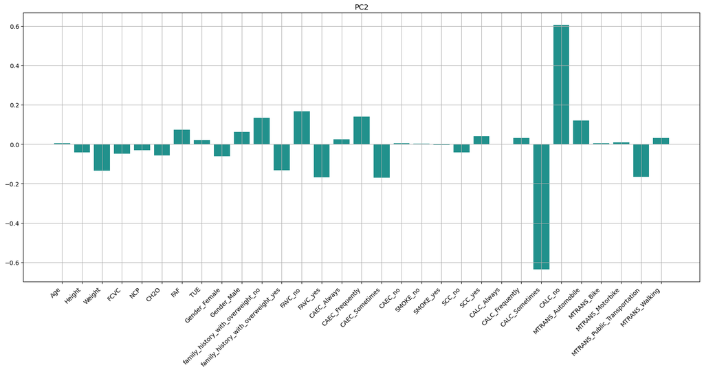

```python
plt.figure(figsize=(20, 8))
plt.bar(np.arange(pca_var.n_features_in_) + 1, pca_var.components_[0, :], color=viridis(0.5))
plt.xticks(ticks=np.arange(pca_var.n_features_in_) + 1,
           labels=[f"{col}" for i, col in enumerate(X_scaled.columns)],
           rotation=45, ha='right')
plt.title('PC1')
plt.grid()
plt.show()

plt.figure(figsize=(20, 8))
plt.bar(np.arange(pca_var.n_features_in_) + 1, pca_var.components_[1, :], color=viridis(0.5))
plt.xticks(ticks=np.arange(pca_var.n_features_in_) + 1,
           labels=[f"{col}" for i, col in enumerate(X_scaled.columns)],
           rotation=45, ha='right')
plt.title('PC2')
plt.grid()
plt.show()
```

## RANDOM FOREST

Il metodo **RandomForest** è un modello di Machine Learning basato su alberi decisionali che è stato introdotto da **Breiman** (2001).

Si tratta di un ensemble di alberi decisionali che lavorano insieme per migliorare le prestazioni predittive e la generalizzazione del modello. L'ensemble usa una tecnica chiamata **bagging** (o **bootstrap aggregation**), che coinvolge la creazione di diversi sottoinsiemi di addestramento utilizzando il bootstrapping (campionamento con sostituzione). Ogni sottoinsieme di addestramento viene poi utilizzato per addestrare un albero decisionale.

**RANDOM FOREST** è un algoritmo di machine learning basato sul concetto di bagging e utilizzato principalmente per la classificazione e la regressione.

**Ensemble Learning.** Random Forest fa parte della famiglia degli algoritmi di ensemble learning. Si basa sull'idea di combinare le previsioni di diversi modelli per ottenere una previsione più robusta e generalizzabile.

**Variabilità nei Modelli.** Per garantire l'indipendenza tra i modelli, durante la creazione di ciascun albero decisionale, viene effettuata una selezione casuale delle caratteristiche da utilizzare in ciascun nodo durante la costruzione dell'albero.

**Voto a Maggioranza.** Durante la fase di predizione, le previsioni di tutti gli alberi vengono combinate attraverso un voto a maggioranza (per la classificazione) o una media (per la regressione) per ottenere il risultato finale del Random Forest.

**Riduzione dell'Overfitting.** L'uso del bagging e della selezione casuale delle caratteristiche aiuta a ridurre l'overfitting, fornendo modelli più stabili e meno sensibili alle variazioni nei dati di addestramento.

**Importanza delle Feature.** Stabilisce quanto una specifica features è determinante per la creazione del modello. Oltre alle previsioni, Random Forest fornisce un'importanza relativa delle caratteristiche, permettendo di identificare quali attributi sono più influenti nel processo decisionale complessivo

Una foresta casuale è un classificatore costituito da un insieme di alberi decisionali, dove ogni albero è costruito applicando un algoritmo $A$ sull'insieme di addestramento $S$ e un vettore casuale aggiuntivo, $\theta$, dove $\theta$ è campionato $i.i.d.$ da una qualche distribuzione. La previsione del RandomForest è ottenuta con un **voto a maggioranza** sulle previsioni dei singoli alberi.

Per specificare una particolare foresta casuale, è necessario definire l'algoritmo $A$ e la distribuzione $\theta$. Innanzitutto, prendiamo un sottocampione casuale da $S$ con sostituzioni; in altre parole, campioniamo un nuovo insieme di allenamento $S_0$ di dimensioni $m_0$ utilizzando la distribuzione uniforme su $S$. In secondo luogo, costruiamo una sequenza $I_1, I_2, \dots$, dove ogni $I_t$ è un sottoinsieme di dimensione $k$, che viene generato campionando uniformemente elementi a caso. Tutte queste variabili casuali formano il vettore $\theta$. Quindi, l'algoritmo $A$ sviluppa un albero decisionale basato sul campione $S_0$, dove a ogni fase di suddivisione dell'algoritmo, esso si limita a scegliere una feature che massimizza il guadagno dall'insieme $I_t$. Intuitivamente, se $k$ è piccolo, questa restrizione può impedire l'overfitting. **[6]**

### GRID SEARCH

Prima di applicare l'algoritmo RandomForest al dataset, si esegua una **grid search** sui parametri più rilevanti con cross validation con $k=10$ fold.

La **CROSS-VALIDATION** è una tecnica utilizzata nell'apprendimento automatico e nella statistica per valutare le prestazioni di un modello predittivo, allo scopo di garantire una robusta generalizzazione su dati non visti. In generale, la cross-validation coinvolge la suddivisione del dataset in più parti, addestrando e valutando il modello su diverse combinazioni di set di addestramento e di test. Una specifica implementazione della cross-validation è la **K-FOLD CROSS-VALIDATION**. In questo approccio, il dataset viene diviso in $K$ parti (fold). Il modello viene addestrato K volte, utilizzando ogni volta una delle $K$ parti come set di test e l'unione delle restanti $K-1$ parti come set di addestramento. Questo processo si ripete $K$ volte, con ogni parte utilizzata esattamente una volta come set di test. Alla fine delle iterazioni, vengono calcolate le medie delle prestazioni del modello per ottenere una valutazione più affidabile delle sue capacità predictive.

In alcune applicazioni, i dati sono scarsi e non si vogliono sprecare per la convalida. La tecnica di **k-fold cross validation** è stata progettata per fornire una stima accurata dell'errore reale senza sprecare troppi dati. Nella convalida incrociata $k$-fold l'insieme di addestramento originale viene suddiviso in k sottoinsiemi (fold) di dimensione $\frac{m}{k}$. Per ogni fold, l'algoritmo viene addestrato sull'unione degli altri fold e poi viene calcolato l'errore. Infine, la media di tutti questi errori è il risultato di una stima dell'errore vero. Il caso speciale $k = m$, dove $m$ è il numero di esempi, è chiamato "leave-one-out" (LOO).

La procedura riceve in ingresso un set di addestramento, $S$, un insieme di possibili valori dei parametri, $\Theta$, un intero, $k$, che rappresenta il numero di folder, e un algoritmo di apprendimento, $A$, che riceve in ingresso un set di allenamento e un parametro $\theta \in \Theta$. L'algoritmo produce il miglior parametro e l'ipotesi addestrata da questo parametro sull'intero set di addestramento. **[6]**

Analizziamo gli **iperparametri** presi in analisi.

1. **oob_score**

   Un indicatore che specifica se utilizzare o meno il metodo "out-of-bag" per stimare l'accuratezza del modello. Se impostato su True, il modello calcolerà l'accuratezza utilizzando i campioni non inclusi durante il bootstrap (out-of-bag samples).
2. **bootstrap**

   Specifica se utilizzare o meno il bootstrapping durante la costruzione degli alberi. Se impostato su True, il modello utilizzerà il campionamento con sostituzione.
3. **criterion**

   La funzione di misura della qualità della divisione dell'albero. Può essere 'gini', 'entropy' o 'log_loss'.
4. **max_depth**

   La profondità massima di ciascun albero nella foresta. Se impostato su None, gli alberi verranno espansi fino a quando ogni foglia contiene meno di min_samples_split campioni.
5. **max_features**

   Il numero massimo di caratteristiche da considerare per la migliore divisione in ciascun albero. Può essere un intero, una frazione o una stringa ('sqrt' per la radice quadrata, 'log2' per il logaritmo base 2, o un valore compreso tra 0 e 1).
6. **min_samples_leaf**

   Il numero minimo di campioni richiesti in una foglia dell'albero.
7. **min_samples_split**

   Il numero minimo di campioni richiesti per suddividere un nodo interno.
8. **n_estimators**

   Il numero totale di alberi nella foresta.
9. **min_impurity_decrease**

   Un nodo verrà suddiviso se la suddivisione induce una diminuzione dell'impurità maggiore o uguale a questo valore.
10. **class_weight**

    Pesi associati alle classi. Può essere 'balanced' o 'balanced_subsample'. 'balanced' regola i pesi inversamente proporzionali al numero di campioni nella classe, 'balanced_subsample' è simile ma considera anche i pesi degli esempi di bootstrapping.

Questi parametri sono utilizzati per regolare il comportamento del modello Random Forest durante il processo di addestramento.

```python
# Definizione Random Forest
rfc = RandomForestClassifier(random_state = 42)

# Griglia di parametri da esplorare
parameters = {
    'oob_score': [True, False],
    'bootstrap': [True],
    'criterion': ['gini', 'entropy', 'log_loss'],
    'max_depth': [10, 20, None],
    'max_features': ["sqrt", "log2", 0.5],
    'min_samples_leaf': [1, 2, 3, 4, 5],
    'min_samples_split': [4, 5, 6, 7],
    'n_estimators': [50],
    'min_impurity_decrease': [0.0, 0.2, 0.5],
    'class_weight': ['balanced', 'balanced_subsample']
}

# Oggetto GridSearchCV, fatto con cross validation su 10 fold e calcolando l'accuracy
grid_rfc = GridSearchCV(estimator=rfc, param_grid=parameters, cv=10,
                        scoring='accuracy', verbose=2, n_jobs=-1)

# Ricerca dei parametri ottimali
grid_rfc.fit(X_train_scaled, y_train)

# Stampa i parametri ottimali
print("Parametri ", grid_rfc.best_params_)
print("Risultato accuracy ", grid_rfc.best_score_)
```

```
Fitting 10 folds for each of 6480 candidates, totalling 64800 fits
Parametri  {'bootstrap': True, 'class_weight': 'balanced_subsample', 'criterion': 'entropy', 'max_depth': 20, 'max_features': 0.5, 'min_impurity_decrease': 0.0, 'min_samples_leaf': 1, 'min_samples_split': 6, 'n_estimators': 50, 'oob_score': True}
Risultato accuracy  0.9626796280642432
```

### APPLICAZIONE RANDOM FOREST

Si applichi ora il **RandomForsetClassifier** al dataset originale con i miglior parametri ottenuti dalla grid search. Grazie all'attributo **features_importance**, è possibile visualizzare l'importanza delle singole varibili per i vari alberi decisionali. Si noti che, dopo aver fatto feature selection escludendo la colonna *CALC_Always*, utilizzando i parametri selezionati dalla grid search, il risultato dell'accuracy risulta **0.9669**.

```
Accuracy: 0.966903073286052
Feature Importance:
1. Feature 3: Weight - Importance: 0.5226585294546251
2. Feature 2: Height - Importance: 0.11107677418383033
3. Feature 4: FCVC - Importance: 0.0650134983921104
4. Feature 1: Age - Importance: 0.05264446049139714
5. Feature 9: Gender_Female - Importance: 0.04602238898419317
6. Feature 10: Gender_Male - Importance: 0.04448508397873833
7. Feature 5: NCP - Importance: 0.019673328210252836
8. Feature 8: TUE - Importance: 0.017737534016438933
9. Feature 6: CH2O - Importance: 0.01635260937236407
10. Feature 7: FAF - Importance: 0.01443486377675627
11. Feature 11: family_history_with_overweight_no - Importance: 0.012466566467923998
12. Feature 12: family_history_with_overweight_yes - Importance: 0.011806708987952927
13. Feature 17: CAEC_Sometimes - Importance: 0.011302602298667738
14. Feature 24: CALC_Sometimes - Importance: 0.008670198644606334
15. Feature 16: CAEC_Frequently - Importance: 0.007983869864789677
16. Feature 13: FAVC_no - Importance: 0.00721912435091437
17. Feature 25: CALC_no - Importance: 0.007059382687434195
18. Feature 14: FAVC_yes - Importance: 0.0069910149605587136
19. Feature 26: MTRANS_Automobile - Importance: 0.00342199507838295
20. Feature 29: MTRANS_Public_Transportation - Importance: 0.003401230355727705
21. Feature 18: CAEC_no - Importance: 0.0016228417872902047
22. Feature 15: CAEC_Always - Importance: 0.0016112689148278377
23. Feature 21: SCC_no - Importance: 0.0015190953467470723
24. Feature 22: SCC_yes - Importance: 0.0013879529707847584
25. Feature 23: CALC_Frequently - Importance: 0.0009878561637052554
26. Feature 30: MTRANS_Walking - Importance: 0.0009682251523542305
27. Feature 19: SMOKE_no - Importance: 0.0006026038718658211
28. Feature 20: SMOKE_yes - Importance: 0.0005453902299207837
29. Feature 27: MTRANS_Bike - Importance: 0.00019734128359021912
30. Feature 28: MTRANS_Motorbike - Importance: 0.0001356597212487168
```

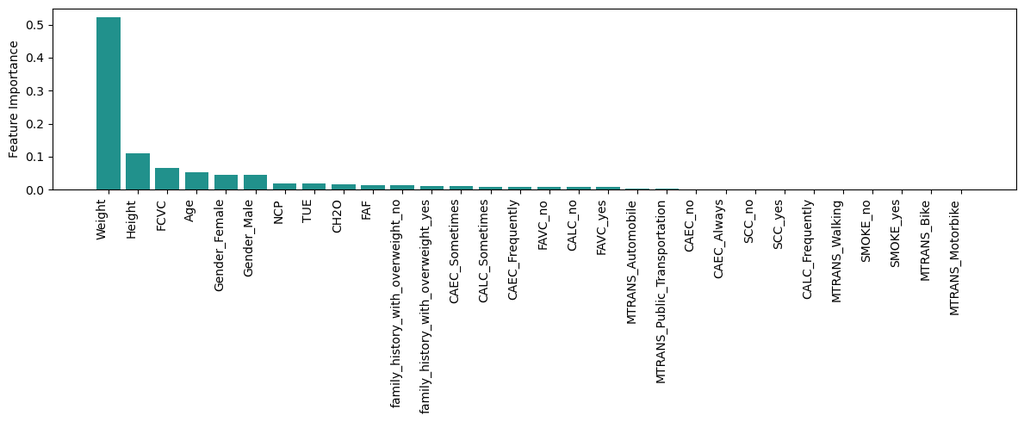

```python
# Addestra il Random Forest sulle componenti principali
rfc = RandomForestClassifier(oob_score = True, bootstrap = True, max_depth = 20,
                             max_features = 0.5, min_samples_leaf = 1,
                             min_samples_split = 6, n_estimators = 1000,
                             min_impurity_decrease = 0.0, class_weight = 'balanced_subsample',
                             criterion = 'entropy', random_state = 42)
# Feature selection
columns_to_exclude = ['CALC_Always']
X_train_drop = X_train_scaled.copy()
X_train_drop = pd.DataFrame(X_train_drop.drop(columns=columns_to_exclude))
X_test_drop = X_test_scaled.copy()
X_test_drop = pd.DataFrame(X_test_drop.drop(columns=columns_to_exclude))
rfc.fit(X_train_drop, y_train)

# Valuta le prestazioni del modello
y_pred = rfc.predict(X_test_drop)
accuracy = accuracy_score(y_test, y_pred)
print(f'Accuracy: {accuracy}')

importances = rfc.feature_importances_
sorted_indices = importances.argsort()[::-1]

print("Feature Importance:")
for i, index in enumerate(sorted_indices):
    print(f"{i + 1}. Feature {index + 1}: {X_train_drop.columns[index]} - Importance: {importances[index]}")

# Plot delle importanze delle feature
fig, ax = plt.subplots(figsize=(12, 5))
ax.bar(range(len(importances)), importances[sorted_indices], color=viridis(0.5))
ax.set_xticks(range(len(importances)))
ax.set_xticklabels(X_train_drop.columns[sorted_indices], rotation=90, ha='right')
ax.set_ylabel("Feature Importance")
fig.tight_layout()
```

### CONFUSION MATRIX

La matrice di confusione (**confusion matrix**) è una tabella che viene utilizzata in problemi di classificazione per valutare le prestazioni di un modello predittivo. Questa matrice mostra il numero di predizioni corrette ed erronee fatte dal modello rispetto alle reali classi di appartenenza degli esempi nel dataset. La matrice è organizzata in modo che ogni riga rappresenti la classe reale, mentre ogni colonna rappresenta la classe predetta dal modello. Ecco una rappresentazione generica di una matrice di confusione binaria

```
                    Classe Preditte
                 |  Positiva  |  Negativa  |
--------------------------------------------
Classe Reale     |    TP      |    FN      |
--------------------------------------------
Classe Reale     |    FP      |    TN      |
```

Dove

- **TP (True Positive)**. I casi in cui il modello ha previsto correttamente la classe positiva
- **FN (False Negative)**. I casi in cui il modello ha previsto erroneamente la classe negativa quando la classe reale è positiva
- **FP (False Positive)**. I casi in cui il modello ha previsto erroneamente la classe positiva quando la classe reale è negativa
- **TN (True Negative)**. I casi in cui il modello ha previsto correttamente la classe negativa

La matrice di confusione fornisce una panoramica completa delle prestazioni di un modello di classificazione, permettendo di calcolare diverse metriche, come l'accuratezza, la precisione, la recall e la F1-score, che sono utili per valutare la qualità delle previsioni del modello. **[9]**

Le metriche di accuracy, recall, precision e F1-score sono comunemente utilizzate per valutare le prestazioni di modelli di classificazione.

1. **Accuracy (Precisione)**
   - L'accuracy misura la percentuale totale di predizioni corrette rispetto al numero totale di predizioni.
   - È definita come `(TP + TN) / (TP + TN + FP + FN)`, dove:
     - TP (True Positives): Numero di casi positivi correttamente predetti
     - TN (True Negatives): Numero di casi negativi correttamente predetti
     - FP (False Positives): Numero di casi negativi predetti come positivi (errore di tipo I)
     - FN (False Negatives): Numero di casi positivi predetti come negativi (errore di tipo II)
1. **Precision (Precisione)**
   - La precision misura la percentuale di predizioni positive corrette rispetto al totale delle predizioni positive effettuate.
   - È definita come `TP / (TP + FP)`
1. **Recall (Recupero o Sensibilità)**
   - Il recall misura la percentuale di casi positivi correttamente predetti rispetto al totale effettivo dei casi positivi
   - È definito come `TP / (TP + FN)`
1. **F1-score:**
   - L'F1-score è una media armonica tra precision e recall. È utile quando si desidera bilanciare precision e recall in situazioni in cui una delle due è più importante dell'altra
   - È definito come `2 * (precision * recall) / (precision + recall)`

```
Classification Report:
                     precision    recall  f1-score   support

Insufficient_Weight       0.97      1.00      0.98        56
      Normal_Weight       0.97      0.90      0.93        62
     Obesity_Type_I       0.97      0.96      0.97        78
    Obesity_Type_II       0.97      0.97      0.97        58
   Obesity_Type_III       1.00      1.00      1.00        63
 Overweight_Level_I       0.91      0.95      0.93        56
Overweight_Level_II       0.98      1.00      0.99        50

           accuracy                           0.97       423
          macro avg       0.97      0.97      0.97       423
       weighted avg       0.97      0.97      0.97       423
```

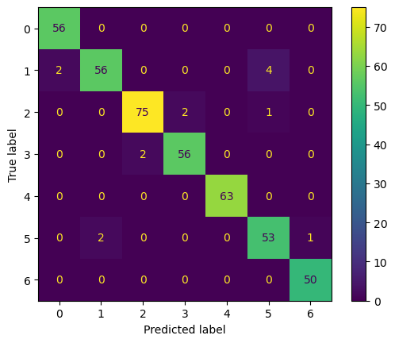

```python
classification_rep = classification_report(y_test, y_pred,
                                           target_names=[class_labels[i] for i in range(7)])
print("Classification Report:")
print(classification_rep)

cm = confusion_matrix(y_test, y_pred, labels=rfc.classes_)
disp = ConfusionMatrixDisplay(confusion_matrix=cm, display_labels=rfc.classes_)
disp.plot(cmap='viridis', values_format='d')
plt.show()
```

### RANDOM FOREST APPLICATO AL DATASET DOPO AVER EFFETTUATO LA PCA

Applichiamo ora il RandomForest al dataset dopo aver eseguito la PCA. Si noti che l'**accuracy** in questo caso risulta essere minore per tutti i casi testati di vazianza spiegata.

```python
for i in [0.70, 0.75, 0.80, 0.85, 0.90, 0.95]:
    explvar_p = i # variare tra 70 e 95
    pca = PCA(explvar_p)

    X_train_pca = pca.fit_transform(X_train_scaled)
    X_test_pca = pca.transform(X_test_scaled)

    # Addestra il Random Forest sulle componenti principali
    rf_classifier = RandomForestClassifier(oob_score = True, bootstrap = True, max_depth = 20,
                                           max_features = 0.5, min_samples_leaf = 1,
                                           min_samples_split = 6, n_estimators = 1000,
                                           min_impurity_decrease = 0.0,
                                           class_weight ='balanced_subsample',
                                           criterion='entropy', random_state = 42)
    rf_classifier.fit(X_train_pca, y_train)

    # Valuta le prestazioni del modello
    y_pred = rf_classifier.predict(X_test_pca)
    accuracy = accuracy_score(y_test, y_pred)
    print(f'Accuracy: {accuracy}, explvar_p: {explvar_p}')
```

```
Accuracy: 0.7966903073286052, explvar_p: 0.7
Accuracy: 0.7943262411347518, explvar_p: 0.75
Accuracy: 0.7966903073286052, explvar_p: 0.8
Accuracy: 0.8014184397163121, explvar_p: 0.85
Accuracy: 0.8132387706855791, explvar_p: 0.9
Accuracy: 0.8203309692671394, explvar_p: 0.95
```

### RANDOM FOREST CLASSIFICAZIONE BINARIA

Si applica ora il **RandomForest** al dataset **binario**.

```python
X_b = pd.DataFrame(df_binary.drop(columns="CLASS")) # Escludo i target
y_b = df_binary["CLASS"]

# Split dei dati in training e test
test_p = 0.2
X_train_b, X_test_b, y_train_b, y_test_b = train_test_split(X_b, y_b, test_size=test_p,
                                                            shuffle=True, random_state=42)

# Standardizziamo i dati
scaler = MinMaxScaler()
scaler.fit(X_train_b) # SOLO dati di training

X_train_scaled_b = pd.DataFrame(scaler.transform(X_train_b), columns=X_train_b.columns)
X_test_scaled_b = pd.DataFrame(scaler.transform(X_test_b), columns=X_test_b.columns)

# Concatena i dati standardizzati
X_scaled = pd.concat([X_train_scaled_b, X_test_scaled_b], axis=0)
```

```
Accuracy: 0.9952718676122931
Classification Report:
              precision    recall  f1-score   support

       Obeso       1.00      0.99      0.99       199
   Non Obeso       0.99      1.00      1.00       224

    accuracy                           1.00       423
   macro avg       1.00      0.99      1.00       423
weighted avg       1.00      1.00      1.00       423

Feature Importance:
1. Feature 3: Weight - Importance: 0.6655698157547895
2. Feature 2: Height - Importance: 0.13769554580058116
3. Feature 12: family_history_with_overweight_yes - Importance: 0.03829478228896785
4. Feature 11: family_history_with_overweight_no - Importance: 0.03607059865714605
5. Feature 1: Age - Importance: 0.02326418596906097
6. Feature 17: CAEC_Sometimes - Importance: 0.016320874159076963
7. Feature 5: NCP - Importance: 0.015848276258322996
8. Feature 10: Gender_Male - Importance: 0.008191747493269647
9. Feature 8: TUE - Importance: 0.008076747236361361
10. Feature 9: Gender_Female - Importance: 0.007936138605113474
11. Feature 4: FCVC - Importance: 0.006902987337260579
12. Feature 24: CALC_Sometimes - Importance: 0.005947978170310787
13. Feature 6: CH2O - Importance: 0.005626957507929055
14. Feature 7: FAF - Importance: 0.005123710157886182
15. Feature 25: CALC_no - Importance: 0.0038856499705148505
16. Feature 16: CAEC_Frequently - Importance: 0.00365933342987217
17. Feature 14: FAVC_yes - Importance: 0.0028916248765314956
18. Feature 13: FAVC_no - Importance: 0.002719416235569244
19. Feature 29: MTRANS_Public_Transportation - Importance: 0.001122012833614189
20. Feature 26: MTRANS_Automobile - Importance: 0.0010676901076024348
21. Feature 23: CALC_Frequently - Importance: 0.0009145595711750542
22. Feature 20: SMOKE_yes - Importance: 0.0007970952614078678
23. Feature 19: SMOKE_no - Importance: 0.0007396265124906105
24. Feature 30: MTRANS_Walking - Importance: 0.0005984081826048618
25. Feature 15: CAEC_Always - Importance: 0.00029579589193522534
26. Feature 28: MTRANS_Motorbike - Importance: 0.00021468084878182642
27. Feature 21: SCC_no - Importance: 0.0001243572351293045
28. Feature 22: SCC_yes - Importance: 8.938012311509047e-05
29. Feature 18: CAEC_no - Importance: 5.368508061232321e-06
30. Feature 27: MTRANS_Bike - Importance: 4.6550155178751805e-06
```

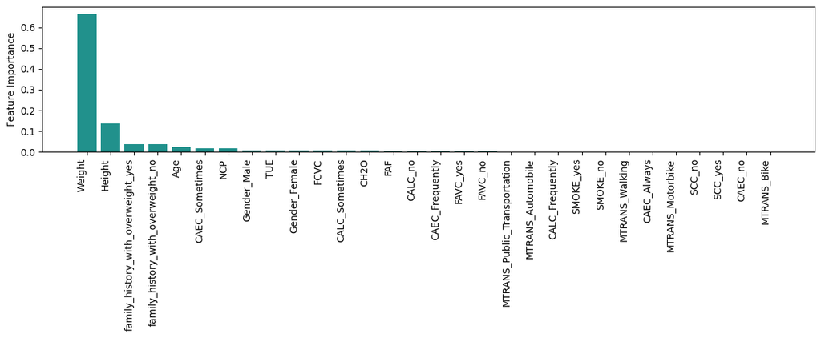

```python
rfc = RandomForestClassifier(oob_score = True, bootstrap = True, max_depth = 20,
                             max_features = 0.5, min_samples_leaf = 1,
                             min_samples_split = 6, n_estimators = 1000,
                             min_impurity_decrease = 0.0, class_weight ='balanced_subsample',
                             criterion='entropy', random_state = 42)
# Feature selection
columns_to_exclude = ['CALC_Always']
X_train_drop = X_train_scaled_b.copy()
X_train_drop = pd.DataFrame(X_train_drop.drop(columns=columns_to_exclude))
X_test_drop = X_test_scaled_b.copy()
X_test_drop = pd.DataFrame(X_test_drop.drop(columns=columns_to_exclude))
rfc.fit(X_train_drop, y_train_b)

# Valuta le prestazioni del modello
y_pred = rfc.predict(X_test_drop)

class_labels = {
    0: 'Obeso',
    1: 'Non Obeso',
}

accuracy = accuracy_score(y_test_b, y_pred)
print(f'Accuracy: {accuracy}')
classification_rep = classification_report(y_test_b, y_pred,
                                           target_names=[class_labels[i] for i in range(2)])
print("Classification Report:")
print(classification_rep)

importances = rfc.feature_importances_
sorted_indices = importances.argsort()[::-1]

print("Feature Importance:")
for i, index in enumerate(sorted_indices):
    print(f"{i + 1}. Feature {index + 1}: {X_train_drop.columns[index]} - Importance: {importances[index]}")

# Plot delle importanze delle feature
fig, ax = plt.subplots(figsize=(12, 5))
ax.bar(range(len(importances)), importances[sorted_indices], color=viridis(0.5))
ax.set_xticks(range(len(importances)))
ax.set_xticklabels(X_train_drop.columns[sorted_indices], rotation=90, ha='right')
ax.set_ylabel("Feature Importance")
fig.tight_layout()
```

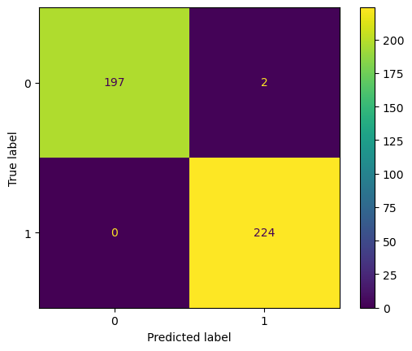

```python
cm = confusion_matrix(y_test_b, y_pred, labels=rfc.classes_)
disp = ConfusionMatrixDisplay(confusion_matrix=cm, display_labels=rfc.classes_)
disp.plot(cmap='viridis', values_format='d')
plt.show()
```

## GRADIENT BOOSTING

Il **BOOSTING** è una tecnica di ensemble learning utilizzata per migliorare le prestazioni di modelli di machine learning combinando in modo sequenziale modelli deboli in un modello più forte. Il **boosting** è un'idea potente che mira a migliorare l'accuratezza di qualsiasi algoritmo di apprendimento, soprattutto quando si tratta di apprendenti deboli. Ovvero di semplici funzioni di predizione che mostrano prestazioni leggermente superiori a quelle di un'ipotesi casuale. Originariamente, il boosting è stato sviluppato per compiti di classificazione binaria, ma può essere prontamente esteso per gestire problemi generali di classificazione e regressione.

**Ensemble Learning Sequenziale.** Il boosting costruisce modelli in modo sequenziale, dando più peso agli esempi che sono stati classificati erroneamente dai modelli precedenti.

**Modelli Deboli.** I modelli utilizzati nel boosting sono spesso chiamati "modelli deboli" o "apprenditori deboli". Possono essere modelli semplici che hanno prestazioni leggermente migliori di un tasso casuale di classificazione.

**Adattamento Progressivo.** Ogni modello debolmente addestrato viene adattato ai dati correggendo gli errori commessi dai modelli precedenti. I pesi degli esempi vengono regolati in modo che gli esempi classificati erroneamente abbiano più peso nel modello successivo.

**Somma Ponderata.** La previsione finale del modello boosting è ottenuta sommando ponderatamente le previsioni dei modelli deboli. Le previsioni dei modelli che hanno avuto una migliore performance durante l'addestramento hanno maggior peso.

**Step-size parameter.** Il parametro di "step-size" γ (anche chiamato "learning rate") è un iperparametro chiave. Questo parametro controlla la dimensione dei passi che l'algoritmo compie nella direzione di minimizzazione della funzione di perdita durante il processo di addestramento. Il valore di γ influisce sulla velocità con cui l'algoritmo di boosting si avvicina alla minimizzazione della perdita di addestramento. Per valori piccoli di γ, l'algoritmo compie passi più piccoli nella direzione di riduzione della perdita. Questo significa che il modello si adatta in modo più lento ai dati di addestramento, poiché ogni passo nella correzione degli errori è più conservativo. La scelta appropriata del parametro di step-size è cruciale per ottenere un buon equilibrio tra la velocità di adattamento e la capacità del modello di generalizzare su nuovi dati.

**Robustezza e Prestazioni.** Il boosting è noto per la sua capacità di migliorare significativamente le prestazioni dei modelli, fornendo modelli complessi e robusti. Tuttavia, può essere sensibile al rumore nei dati di addestramento.

**GRADIENT BOOSTING** è una tecnica di machine learning che appartiene alla famiglia degli algoritmi di boosting. Questo approccio costruisce un modello predittivo in modo sequenziale, migliorando progressivamente le prestazioni mediante la correzione degli errori commessi dai modelli precedenti. L'idea principale è quella di imitare un algoritmo di discesa del gradiente

- Calcolare un gradiente negativo su 𝑛 punti di addestramento
- Adattare un modello semplice per approssimare il gradiente
- Eseguire un passo di dimensioni 𝛾 nella direzione del gradiente negativo

Uno dei principali progressi nella teoria del boosting è stato il riconoscimento che è possibile utilizzare un **metodo di discesa del gradiente** simile per qualsiasi funzione di Loss. L'algoritmo di discesa del gradiente è chiamato **GRADIENT BOOSTING**. L'idea principale è quella di imitare un algoritmo di discesa del gradiente. In ogni fase della procedura di boosting, si calcola un gradiente negativo su $n$ punti di addestramento $x_1, \dots, x_n$. Quindi, si inserisce un modello semplice (ad esempio un albero decisionale poco profondo) per approssimare il gradiente per qualsiasi caratteristica $x$. Infine, come nel metodo della discesa del gradiente, facciamo un passo nella direzione del gradiente negativo. **[10]**

L'approssimazione del gradiente negativo avviene risolvedo il seguente problema $$h_b = \underset{h \in H}{\text{argmin}} \frac{1}{n} \sum_{i=1}^{n} \left( r_i^{(b)} - [g_{b-1}(x_i) + h(x_i)] \right)^2 $$

Dove

- $b \in [1, B]$
- $B$ è il numero di boosting
- $r_i^{(b)} = -\frac{\partial Loss(y_i, z)}{\partial z}$, con $z=g_{b-1}(x_i)$
- $g_b$ è la gradient boosting prediction function

### GRID SEARCH

Prima di applicare l'algoritmo GradientBoosting al dataset, si esegua una **grid search** sui parametri più rilevanti con cross validation con $k=5$. **[11]**

Ecco una descrizione dei parametri forniti per il modello di Gradient Boosting:

1. **loss**

   La funzione di perdita da minimizzare durante la costruzione dell'albero. Nella tua configurazione, è fissato su 'log_loss', che è spesso utilizzato per problemi di classificazione binaria.
2. **learning_rate**

   Il tasso di apprendimento controlla la contribuzione di ciascun albero alla correzione degli errori del modello. Valori più bassi rendono il modello più robusto, ma richiedono più alberi per ottenere una buona performance.
3. **n_estimators**

   Il numero totale di alberi da addestrare nella sequenza di boosting.
4. **subsample**

   La frazione di campioni utilizzati per l'addestramento di ciascun albero. Valori inferiori introducono stocasticità e possono rendere il modello più robusto.
5. **criterion**

   La funzione di misura della qualità della divisione dell'albero. Può essere 'friedman_mse' o 'squared_error'.
6. **min_samples_split**

   Il numero minimo di campioni richiesti per suddividere un nodo interno.
7. **min_samples_leaf**

   Il numero minimo di campioni richiesti in una foglia dell'albero.
8. **min_weight_fraction_leaf**

   La frazione minima del peso totale di un nodo foglia necessaria per considerare la foglia come foglia valida.
9. **max_depth**

   La profondità massima di ciascun albero nella sequenza di boosting. Se impostato su None, gli alberi verranno espansi fino a quando ogni foglia contiene meno di min_samples_split campioni.
10. **min_impurity_decrease**

    Un nodo verrà suddiviso se la suddivisione induce una diminuzione dell'impurità maggiore o uguale a questo valore.
11. **max_features**

    Il numero massimo di caratteristiche da considerare per la migliore divisione in ciascun albero. Può essere un intero, una frazione o una stringa ('sqrt' per la radice quadrata, 'log2' per il logaritmo base 2, o un valore compreso tra 0 e 1).

Questi parametri sono utilizzati per regolare il comportamento del modello di Gradient Boosting durante il processo di addestramento.

```python
gbc = GradientBoostingClassifier(random_state = 42)

# Griglia di parametri da esplorare
parameters = {
    'loss': ['log_loss'],
    'learning_rate': [0, 1, 100],
    'n_estimators': [50],
    'subsample': [0.01, 0.5, 1],
    'criterion': ["friedman_mse", "squared_error"],
    'min_samples_split': [0.5, 2, 10],
    'min_samples_leaf': [1, 2, 3,],
    'min_weight_fraction_leaf': [0, 0.5],
    'max_depth': [20, None],
    'min_impurity_decrease': [0, 0.5, 1],
    'max_features':['sqrt', 'log2', 0.5]
}

# Oggetto GridSearchCV, fatto con cross validation su 5 fold e calcolando l'accuracy
grid_gbc = GridSearchCV(estimator=gbc, param_grid=parameters, cv=5,
                        scoring='accuracy', verbose=2, n_jobs=-1)

# Ricerca dei parametri ottimali
grid_gbc.fit(X_train_scaled, y_train)

# Stampa i parametri ottimali
print("Parametri ", grid_gbc.best_params_)
print("Risultato accuracy ", grid_gbc.best_score_)
```

```
Fitting 5 folds for each of 5832 candidates, totalling 29160 fits
Parametri  {'criterion': 'friedman_mse', 'learning_rate': 1, 'loss': 'log_loss', 'max_depth': None, 'max_features': 0.5, 'min_impurity_decrease': 0, 'min_samples_leaf': 2, 'min_samples_split': 2, 'min_weight_fraction_leaf': 0, 'n_estimators': 50, 'subsample': 1}
Risultato accuracy  0.9472688005899601
```

### APPLICAZIONE GRADIENT BOOSTING

```
Accuracy: 0.9527186761229315
Feature Importance:
1. Feature 3: Weight - Importance: 0.4198117607278499
2. Feature 2: Height - Importance: 0.18579610114572803
3. Feature 4: FCVC - Importance: 0.07438576066706273
4. Feature 1: Age - Importance: 0.06490652883364163
5. Feature 10: Gender_Male - Importance: 0.050192987949624734
6. Feature 23: CALC_Sometimes - Importance: 0.03353090994739867
7. Feature 6: CH2O - Importance: 0.033382549628632525
8. Feature 8: TUE - Importance: 0.0299103910371153
9. Feature 7: FAF - Importance: 0.020116470389577566
10. Feature 12: family_history_with_overweight_yes - Importance: 0.015899851465348225
11. Feature 5: NCP - Importance: 0.013231298169886089
12. Feature 18: CAEC_no - Importance: 0.010448691344936537
13. Feature 16: CAEC_Frequently - Importance: 0.009478086547974414
14. Feature 14: FAVC_yes - Importance: 0.009350476624063494
15. Feature 13: FAVC_no - Importance: 0.007838068449101024
16. Feature 28: MTRANS_Walking - Importance: 0.0035905188258310602
17. Feature 20: SCC_no - Importance: 0.0035567580410222374
18. Feature 24: CALC_no - Importance: 0.0029927182913627825
19. Feature 15: CAEC_Always - Importance: 0.0025383684521977125
20. Feature 17: CAEC_Sometimes - Importance: 0.0022984488405151837
21. Feature 19: SMOKE_yes - Importance: 0.001952141569827146
22. Feature 27: MTRANS_Public_Transportation - Importance: 0.001485380179411125
23. Feature 25: MTRANS_Automobile - Importance: 0.0014054055750449337
24. Feature 9: Gender_Female - Importance: 0.0011729234795089679
25. Feature 21: SCC_yes - Importance: 0.00034989839340158753
26. Feature 22: CALC_Frequently - Importance: 0.000328462666238208
27. Feature 11: family_history_with_overweight_no - Importance: 4.887237655218646e-05
28. Feature 26: MTRANS_Bike - Importance: 1.703811459042635e-07
```

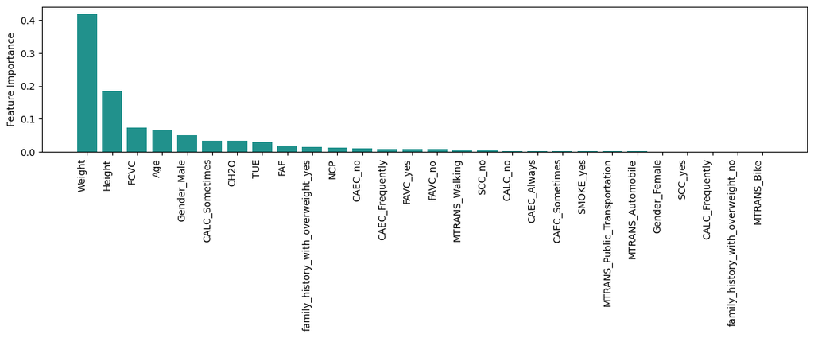

```python
# Addestra il modello di boosting
gbc = GradientBoostingClassifier(criterion='friedman_mse', learning_rate=1,
                                 loss='log_loss', max_depth=None, max_features=0.5,
                                 min_impurity_decrease=0, min_samples_leaf=2,
                                 min_samples_split=2, min_weight_fraction_leaf=0,
                                 n_estimators=1000, subsample=1, random_state=42)

columns_to_exclude = ['CALC_Always', 'MTRANS_Motorbike', 'SMOKE_no']
X_train_drop = X_train_scaled.copy()
X_train_drop = pd.DataFrame(X_train_drop.drop(columns=columns_to_exclude))
X_test_drop = X_test_scaled.copy()
X_test_drop = pd.DataFrame(X_test_drop.drop(columns=columns_to_exclude))
gbc.fit(X_train_drop, y_train)

# Valuta le prestazioni del modello
y_pred = gbc.predict(X_test_drop)
accuracy = accuracy_score(y_test, y_pred)
print(f'Accuracy: {accuracy}')

# Calcola l'importanza delle feature dell'ensemble
importances = gbc.feature_importances_
sorted_indices = importances.argsort()[::-1]

print("Feature Importance:")
for i, index in enumerate(sorted_indices):
    print(f"{i + 1}. Feature {index + 1}: {X_train_drop.columns[index]} - Importance: {importances[index]}")

# Plot delle importanze delle feature
fig, ax = plt.subplots(figsize=(12, 5))
ax.bar(range(len(importances)), importances[sorted_indices], color=viridis(0.5))
ax.set_xticks(range(len(importances)))
ax.set_xticklabels(X_train_drop.columns[sorted_indices], rotation=90, ha='right')
ax.set_ylabel("Feature Importance")
fig.tight_layout()
```

### CONFUSION MATRIX

```
Classification Report:
                     precision    recall  f1-score   support

Insufficient_Weight       0.97      1.00      0.98        56
      Normal_Weight       0.90      0.92      0.91        62
     Obesity_Type_I       0.97      0.95      0.96        78
    Obesity_Type_II       0.97      0.98      0.97        58
   Obesity_Type_III       1.00      1.00      1.00        63
 Overweight_Level_I       0.92      0.88      0.90        56
Overweight_Level_II       0.92      0.94      0.93        50

           accuracy                           0.95       423
          macro avg       0.95      0.95      0.95       423
       weighted avg       0.95      0.95      0.95       423
```

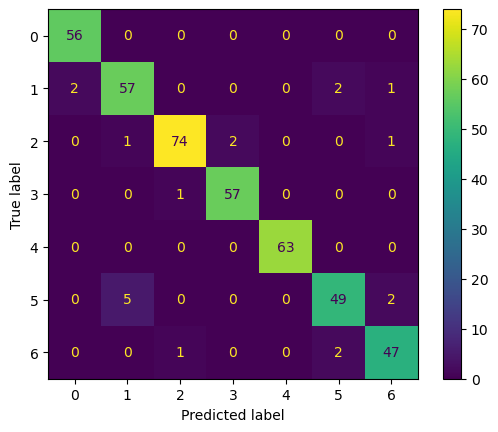

```python
classification_rep = classification_report(y_test, y_pred,
                                           target_names=[class_labels[i] for i in range(7)])
print("Classification Report:")
print(classification_rep)

cm = confusion_matrix(y_test, y_pred, labels=gbc.classes_)
disp = ConfusionMatrixDisplay(confusion_matrix=cm, display_labels=gbc.classes_)
disp.plot(cmap='viridis', values_format='d')
plt.show()
```

### GRADIENT BOOSTING APPLICATO AL DATASET DOPO AVER EFFETTUATO LA PCA

Applichiamo ora il GradientBoosting al dataset dopo aver eseguito la PCA. Si noti che l'**accuracy** in questo caso risulta essere minore per tutti i casi testati di vazianza spiegata.

```python
for i in [0.70, 0.75, 0.80, 0.85, 0.90, 0.95]:
    explvar_p = i # variare tra 70 e 95
    pca = PCA(explvar_p)

    X_train_pca = pca.fit_transform(X_train_scaled)
    X_test_pca = pca.transform(X_test_scaled)

    # Addestra il Random Forest sulle componenti principali
    gbc = GradientBoostingClassifier(criterion='friedman_mse', learning_rate=1,
                                     loss='log_loss', max_depth=None, max_features=0.5,
                                     min_impurity_decrease=0, min_samples_leaf=2,
                                     min_samples_split=2, min_weight_fraction_leaf=0,
                                     n_estimators=1000, subsample=1, random_state=42)
    gbc.fit(X_train_pca, y_train)

    # Valuta le prestazioni del modello
    y_pred = gbc.predict(X_test_pca)
    accuracy = accuracy_score(y_test, y_pred)
    print(f'Accuracy: {accuracy}, explvar_p: {explvar_p}')
```

```
Accuracy: 0.7754137115839244, explvar_p: 0.7
Accuracy: 0.7683215130023641, explvar_p: 0.75
Accuracy: 0.7754137115839244, explvar_p: 0.8
Accuracy: 0.7872340425531915, explvar_p: 0.85
Accuracy: 0.789598108747045, explvar_p: 0.9
Accuracy: 0.7825059101654847, explvar_p: 0.95
```

### GRADIENT BOOSTING CLASSIFICAZIONE BINARIA

Si applica ora il **GradientBoosting** al dataset **binario**.

```python
X_b = pd.DataFrame(df_binary.drop(columns="CLASS")) # Escludo i target
y_b = df_binary["CLASS"]

# Split dei dati in training e test
test_p = 0.2
X_train_b, X_test_b, y_train_b, y_test_b = train_test_split(X_b, y_b, test_size=test_p,
                                                            shuffle=True, random_state=42)

# Standardizziamo i dati
scaler = MinMaxScaler()
scaler.fit(X_train_b) # SOLO dati di training

X_train_scaled_b = pd.DataFrame(scaler.transform(X_train_b), columns=X_train_b.columns)
X_test_scaled_b = pd.DataFrame(scaler.transform(X_test_b), columns=X_test_b.columns)

# Concatena i dati standardizzati
X_scaled = pd.concat([X_train_scaled_b, X_test_scaled_b], axis=0)
```

```
Accuracy: 0.9952718676122931
Classification Report:
              precision    recall  f1-score   support

       Obeso       0.99      0.99      0.99       199
   Non Obeso       1.00      1.00      1.00       224

    accuracy                           1.00       423
   macro avg       1.00      1.00      1.00       423
weighted avg       1.00      1.00      1.00       423

Feature Importance:
1. Feature 3: Weight - Importance: 0.8206788835753484
2. Feature 2: Height - Importance: 0.07462762482520661
3. Feature 1: Age - Importance: 0.04889802157356662
4. Feature 14: FAVC_yes - Importance: 0.01771322554297722
5. Feature 23: CALC_Sometimes - Importance: 0.014386985842107186
6. Feature 5: NCP - Importance: 0.005061462380565682
7. Feature 4: FCVC - Importance: 0.004846186419470694
8. Feature 24: CALC_no - Importance: 0.0030433907595354697
9. Feature 19: SMOKE_yes - Importance: 0.0026317454843893576
10. Feature 8: TUE - Importance: 0.0017247503524649476
11. Feature 7: FAF - Importance: 0.0013251394169559603
12. Feature 28: MTRANS_Walking - Importance: 0.0012165099927207838
13. Feature 12: family_history_with_overweight_yes - Importance: 0.001209209534032779
14. Feature 10: Gender_Male - Importance: 0.0007649466978184187
15. Feature 17: CAEC_Sometimes - Importance: 0.0005859032681023487
16. Feature 9: Gender_Female - Importance: 0.00047655456891207643
17. Feature 6: CH2O - Importance: 0.0003502006653469425
18. Feature 13: FAVC_no - Importance: 0.0002666159788060871
19. Feature 27: MTRANS_Public_Transportation - Importance: 0.00013410685165651172
20. Feature 11: family_history_with_overweight_no - Importance: 2.2045875642636877e-05
21. Feature 22: CALC_Frequently - Importance: 1.702864867998092e-05
22. Feature 25: MTRANS_Automobile - Importance: 8.418809325726111e-06
23. Feature 16: CAEC_Frequently - Importance: 7.598669613639448e-06
24. Feature 20: SCC_no - Importance: 3.335393811340483e-06
25. Feature 15: CAEC_Always - Importance: 1.0074488933247882e-07
26. Feature 21: SCC_yes - Importance: 7.669370923896914e-09
27. Feature 18: CAEC_no - Importance: 4.5868242785593186e-10
28. Feature 26: MTRANS_Bike - Importance: 0.0
```

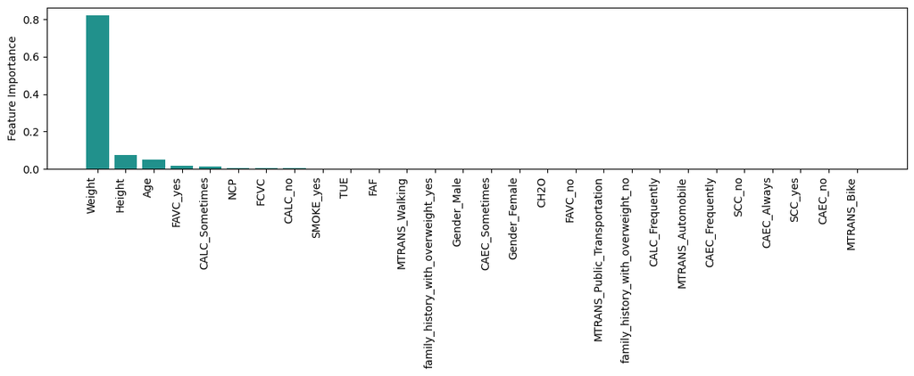

```python
gbc = GradientBoostingClassifier(criterion='friedman_mse', learning_rate=1,
                                 loss='log_loss', max_depth=None, max_features=0.5,
                                 min_impurity_decrease=0, min_samples_leaf=2,
                                 min_samples_split=2, min_weight_fraction_leaf=0,
                                 n_estimators=1000, subsample=1, random_state=42)

columns_to_exclude = ['CALC_Always', 'MTRANS_Motorbike', 'SMOKE_no']
X_train_drop = X_train_scaled_b.copy()
X_train_drop = pd.DataFrame(X_train_drop.drop(columns=columns_to_exclude))
X_test_drop = X_test_scaled_b.copy()
X_test_drop = pd.DataFrame(X_test_drop.drop(columns=columns_to_exclude))
gbc.fit(X_train_drop, y_train_b)

# Valuta le prestazioni del modello
y_pred = gbc.predict(X_test_drop)

class_labels = {
    0: 'Obeso',
    1: 'Non Obeso',
}
accuracy = accuracy_score(y_test_b, y_pred)
print(f'Accuracy: {accuracy}')
classification_rep = classification_report(y_test_b, y_pred,
                                           target_names=[class_labels[i] for i in range(2)])
print("Classification Report:")
print(classification_rep)


importances = gbc.feature_importances_
sorted_indices = importances.argsort()[::-1]

print("Feature Importance:")
for i, index in enumerate(sorted_indices):
    print(f"{i + 1}. Feature {index + 1}: {X_train_drop.columns[index]} - Importance: {importances[index]}")

# Plot delle importanze delle feature
fig, ax = plt.subplots(figsize=(12, 5))
ax.bar(range(len(importances)), importances[sorted_indices], color=viridis(0.5))
ax.set_xticks(range(len(importances)))
ax.set_xticklabels(X_train_drop.columns[sorted_indices], rotation=90, ha='right')
ax.set_ylabel("Feature Importance")
fig.tight_layout()
```

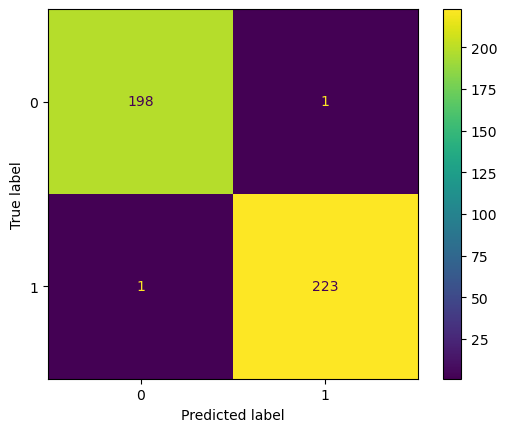

```python
cm = confusion_matrix(y_test_b, y_pred, labels=gbc.classes_)
disp = ConfusionMatrixDisplay(confusion_matrix=cm, display_labels=gbc.classes_)
disp.plot(cmap='viridis', values_format='d')
plt.show()
```

## CONCLUSIONI

Nel corso dell'elaborato sono stati analizzati due algoritmi di classificazione e un algoritmo di apprendimento non supervisionato.

Nello specifico, una volta effettuata l'esplorazione e visualizzazione del dataset, si è applicata la **PCA**.

Successivamente, si sono implementati due metodi di classificazione, **RandomForest** e **GradientBoosting**. Si sono applicati al dataset originale. Quindi si è anche verificata una classificazione binaria. In ultimo, si sono applicati i modelli al dataframe dopo aver applicato la PCA.

Il Random Forest si è distinto come il modello con le prestazioni più elevate, raggiungendo un'accuratezza di **0.9669**. Anche se il GradientBoosting ha ottenuto un'accuracy di **0.9527**, quindi altrettanto elevata.

In tutti questi modelli infine, l'ottimizzazione degli iperparametri attraverso Grid Search con Cross Validation e la selezione delle features ha svolto un ruolo chiave nel massimizzare le prestazioni di ciascun modello e abbassare il rischio di overfitting.

## REFERENCES

[1] https://archive.ics.uci.edu/dataset/544/estimation+of+obesity+levels+based+on+eating+habits+and+physical+condition

[2] https://www.epicentro.iss.it/obesita/report-obesita-oms-2022

[3] https://www.sciencedirect.com/science/article/pii/S2352340919306985?via%3Dihub

[4] https://scikit-learn.org/stable/modules/generated/sklearn.preprocessing.LabelEncoder.html

[5] https://scikit-learn.org/stable/modules/generated/sklearn.preprocessing.OneHotEncoder.html#sklearn.preprocessing.OneHotEncoder

[6] Shalev-Shwartz, S., & Ben-David, S. (2014). **Understanding Machine Learning: From Theory to Algorithms.** Cambridge University Press.

[7] https://scikit-learn.org/stable/modules/generated/sklearn.preprocessing.MinMaxScaler.html

[8] https://scikit-learn.org/stable/modules/generated/sklearn.ensemble.RandomForestClassifier.html

[9] https://scikit-learn.org/stable/modules/generated/sklearn.metrics.confusion_matrix.html

[10] Kroese, D. P., Botev, Z. I., Taimre, T., & Vaisman, R. (2020, November 25). **Data Science and Machine Learning: Mathematical and Statistical Methods.**

[11] https://scikit-learn.org/stable/modules/generated/sklearn.ensemble.GradientBoostingClassifier.html